# Taller de Fundamentos Estadísticos para Finanzas Analíticas

Taller de Matemáticas avanzadas para finanzas — Fundamentos Estadísticos para Finanzas Analíticas

Autor/a

Palacio Esteban, Duarte Sebastian

Fecha de publicación

22 de agosto de 2026

Parámetros globales

# 1 Punto I. Riesgo de mercado: URTH y BNO

Se analizan los ETF **iShares MSCI World (URTH)** —proxy del mercado accionario global desarrollado— y **United States Brent Oil Fund (BNO)** —factor de exposición al precio internacional del petróleo Brent—, con precios de cierre diarios de los últimos cuatro años.

```
Observaciones de precios: 1004 | Rango: 2022-08-22 a 2026-08-21
```

## 1.1 a.i) Estadística descriptiva de los retornos

Estadísticos descriptivos de los retornos diarios

| Activo | N | Media_Diaria | Mediana | Media_Geometrica | Desv_Estandar | Semidesviacion | Percentil_2 | Percentil_99 | Asimetria | Curtosis_Exceso | Minimo | Maximo |
| --- | --- | --- | --- | --- | --- | --- | --- | --- | --- | --- | --- | --- |
| URTH | 1003 | 0.000661 | 0.000820 | 0.000661 | 0.009661 | 0.006525 | -0.018507 | 0.023340 | 0.285812 | 9.134902 | -0.062832 | 0.085592 |
| BNO | 1003 | 0.000573 | 0.001249 | 0.000573 | 0.021809 | 0.015412 | -0.046297 | 0.057208 | -0.165818 | 2.317980 | -0.108438 | 0.091297 |

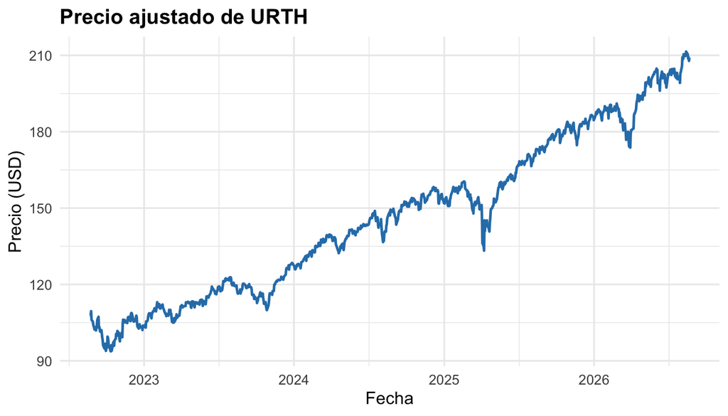

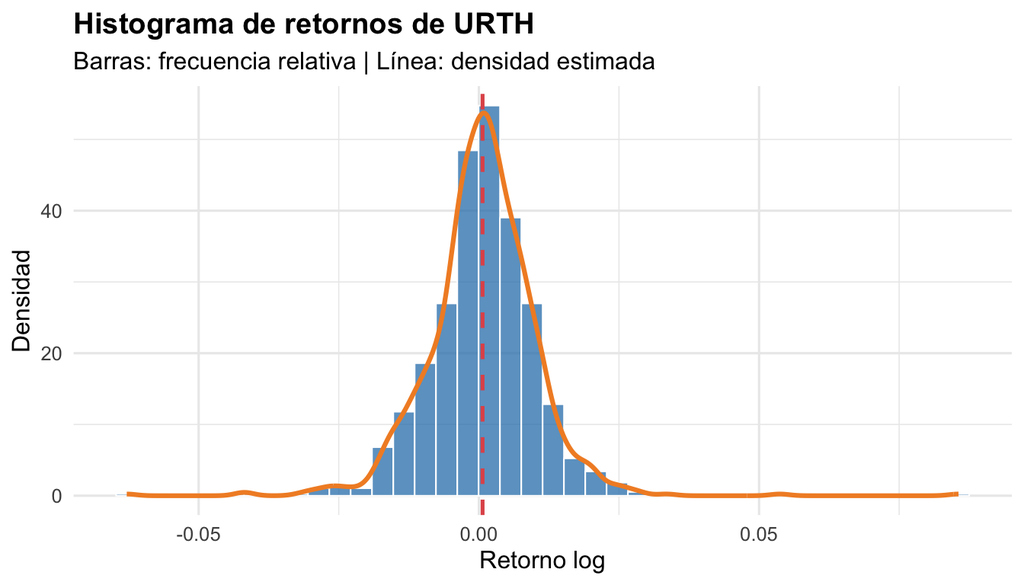

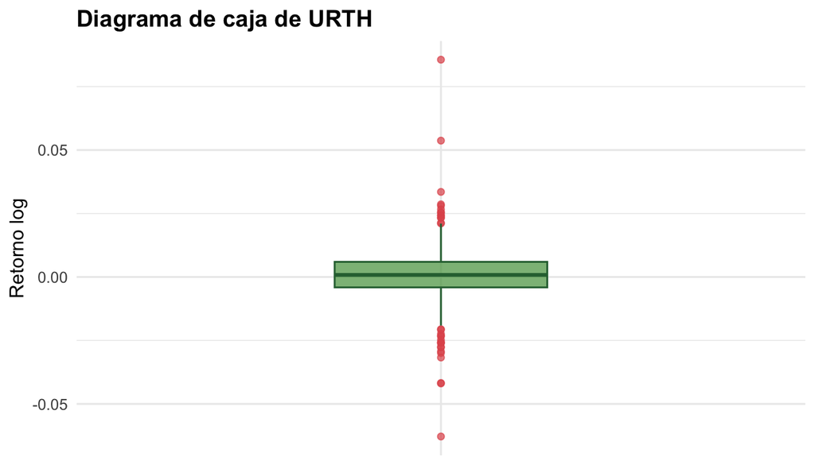

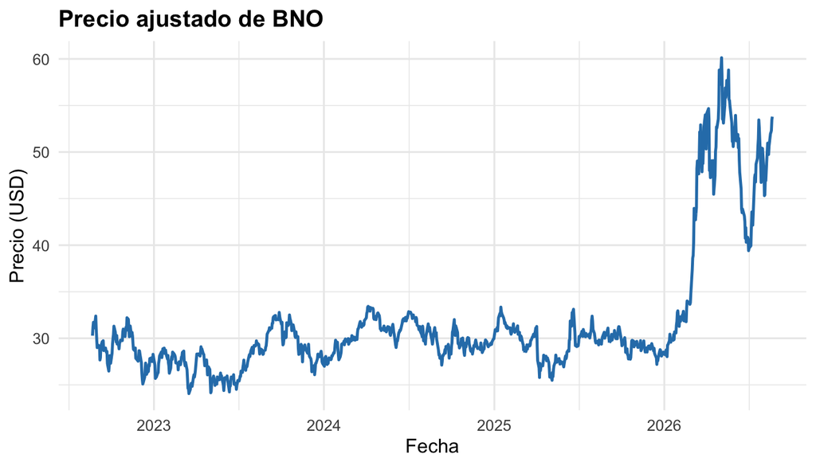

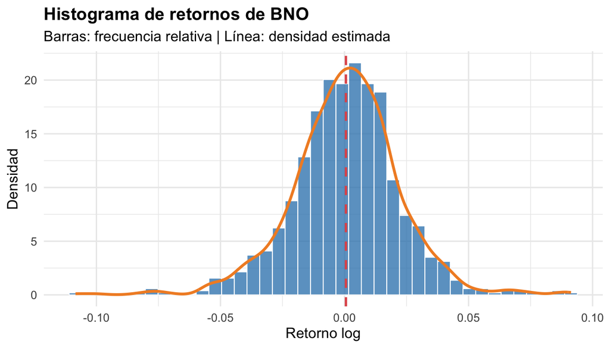

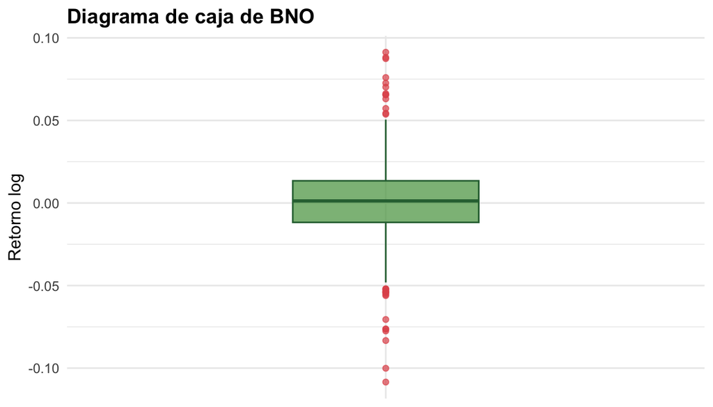

La muestra abarca 1003 observaciones diarias (≈ 4 años) para cada activo.

**Tendencia central.** El retorno medio diario de URTH es 0.066%, muy cercano a su mediana (0.082%) —la mediana levemente por encima sugiere que algún día muy negativo jala la media hacia abajo— y a su media geométrica, el retorno compuesto efectivo (0.066%). BNO promedia 0.057% diario, con una lectura igual de consistente entre sus tres medidas de tendencia central.

**Forma de la distribución: asimetría y curtosis.** Ambas series son **leptocúrticas** (curtosis en exceso > 0): tienen colas más pesadas que la Normal, es decir, los eventos extremos son más frecuentes de lo que predeciría una campana de Gauss. Pero de forma distinta. **URTH** tiene curtosis extrema (9.13) y asimetría positiva (0.29) —un alargamiento de la cola **derecha**— dominado por un único día atípico de 8.56% (su máximo), un *outlier* que por sí solo dispara la curtosis. **BNO** tiene curtosis moderada (2.32) pero asimetría negativa (-0.17) —un alargamiento de la cola **izquierda**— concentrado en su día de -10.84%, más allá del percentil 2% (-4.63%).

Estos *outliers* condicionan fuertemente la distribución que se ajuste y las estimaciones de riesgo de cola: un único día extremo puede inflar el VaR/CVaR y, con ello, las provisiones y el capital en riesgo, por lo que conviene identificarlos y decidir si son ruido, error de dato o un evento de régimen que podría repetirse. La cola que más importa para la gestión de riesgo es la **izquierda (retornos < 0)**, la que materializa pérdidas; el signo de la asimetría indica de qué lado es más probable el evento extremo (a la baja en BNO, al alza en URTH).

## 1.2 a.ii) Regla empírica: intervalo de ±2 desviaciones estándar (URTH)

Intervalo media ± 2σ para los retornos diarios de URTH

| Media | Desv_Estandar | Limite_Inferior | Limite_Superior | Cobertura_Empirica |
| --- | --- | --- | --- | --- |
| 0.00066 | 0.00966 | -0.01866 | 0.01998 | 0.95912 |

**Interpretación.** Del literal a.i sabemos que la distribución de URTH es **acampanada** (aunque aún no sabemos cuál es en concreto). El intervalo de dos desviaciones estándar alrededor de la media es **μ ± 2σ = [-1.87%, 2.00%]**, y sobre los datos **el 95.9% de los retornos diarios observados cae efectivamente dentro de esa banda**. Por eso sirve como referencia de un “día normal” y para construir **escenarios de estrés moderado**: fija rangos razonables de variación y límites de alerta. No obstante, esto describe el **pasado** del activo: es posible pero **no imposible** un movimiento a **jσ ; j > 2**. Ese movimiento sí llega a darse: de hecho ocurre en el **4.1%** de los días que la regla empírica de 2σ no alcanza a cubrir.

## 1.3 a.iii) Covarianza y correlación entre URTH y BNO

Matriz de covarianzas (diaria)

|  | URTH | BNO |
| --- | --- | --- |
| URTH | 0.00009333 | 0.00001014 |
| BNO | 0.00001014 | 0.00047565 |

Matriz de correlaciones

|  | URTH | BNO |
| --- | --- | --- |
| URTH | 1.0000 | 0.0481 |
| BNO | 0.0481 | 1.0000 |

**Interpretación — Covarianza.** La covarianza se interpreta por su **signo**, no por su magnitud (que depende de las escalas de las variables): una covarianza mayor que 0 indica una **relación lineal directa** —las variables tienden a moverse en el mismo sentido— y una covarianza de 0 indica que **no existe relación lineal**. En este caso la covarianza entre URTH y BNO es 0.0000101: el signo es positivo, lo que en principio apuntaría a una relación directa, pero su valor es tan pequeño que a efectos prácticos puede considerarse **≈ 0**, es decir, sin relación lineal apreciable.

**Interpretación — Correlación.** La correlación estandariza esa covarianza al rango [−1, 1] y la hace interpretable en magnitud. Aquí es 0.048: como su valor absoluto es menor a 0.3, bajo el criterio visto en clase concluimos que **no existe relación lineal** entre URTH y BNO; el signo positivo, ya casi nulo, apenas señala una tendencia mínima a moverse en el mismo sentido. Ambas medidas coinciden, entonces, en que el mercado accionario global (URTH) y el petróleo Brent (BNO) responden a **factores distintos**, por lo que combinarlos aporta diversificación (el comportamiento de uno no se explica linealmente por el del otro). De hecho, una correlación tan cercana a cero está próxima al **caso ideal** ($\rho \to 0$): combinar ambos activos reduce el riesgo casi al máximo posible, porque sus movimientos apenas se solapan. Cabe la salvedad de que “no correlacionado” **no significa “independiente”** —podría existir dependencia no lineal o de colas (caer juntos en un pánico)— y de que esta es una estimación **muestral** de 4 años, que puede cambiar en otros periodos y tiende a **aumentar en episodios de estrés**.

## 1.4 b) VaR y CVaR al 95% — Exposición a BNO (factor energético)

Una exposición de $100,000,000 a BNO equivale a estar **largo en crudo** (BNO replica el precio *spot* del Brent). Estimamos el VaR y el CVaR al 95% para un día por **simulación histórica**, con la convención estándar de gestión de riesgos: la pérdida es el cuantil de la **cola izquierda** de los retornos.

VaR y CVaR al 95% (1 día) — exposición USD 100M a BNO

| Metodo | Distribucion | Confianza | Cuantil_Cola | VaR_Pct | CVaR_Pct | VaR_Monetario | CVaR_Monetario |
| --- | --- | --- | --- | --- | --- | --- | --- |
| Simulación histórica | Empírica (BNO) | 0.95 | -0.036 | 3.602 | 4.946 | 3601770 | 4946224 |

**Interpretación.** Con la exposición de $100,000,000, la simulación histórica arroja un **VaR al 95% de 3.60%** ($3,601,770) y un **CVaR de 4.95%** ($4,946,224): en el peor 5% de los días la pérdida sería de al menos ese monto, y el CVaR mide cuán severa es en promedio cuando se cruza ese umbral. El VaR mide, en definitiva, la **magnitud del movimiento adverso diario** del factor Brent.

**Cómo afecta según el tipo de empresa.** Qué extremo es “adverso” depende del negocio:

- Una **empresa productora/vendedora de crudo** (o larga en BNO) pierde cuando el precio **cae** —justo la cola que mide este VaR—: vendería a un precio menor, con **ingreso y ganancia que deja de percibir**. Su cobertura natural es asegurar un precio mínimo de venta.
- Una **empresa dependiente del crudo para sus costos** (transporte, manufactura, aviación) pierde cuando el precio **sube**. Como los retornos diarios del Brent son casi **simétricos**, esta misma magnitud (≈ 3.60% diario) aproxima su exposición, solo que el escenario adverso es el opuesto: el **encarecimiento del insumo golpea los costos operativos y los márgenes**. Su cobertura natural es asegurar el precio de compra (posiciones que ganan cuando el crudo sube).

Dada la magnitud (≈ $4,946,224 en la cola), se justifican **estrategias de cobertura** sobre el Brent; el CVaR dimensiona el colchón de capital/margen para los días extremos.

## 1.5 c) VaR y CVaR al 95% — Exposición a URTH (entorno global)

VaR y CVaR al 95% (1 día) — exposición USD 100M a URTH

| Metodo | Distribucion | Confianza | Cuantil_Cola | VaR_Pct | CVaR_Pct | VaR_Monetario | CVaR_Monetario |
| --- | --- | --- | --- | --- | --- | --- | --- |
| Simulación histórica | Empírica (URTH) | 0.95 | -0.015 | 1.475 | 2.091 | 1475279 | 2090563 |

**Interpretación.** El **VaR al 95% de URTH es 1.48% ($1,475,279)** y el **CVaR 2.09% ($2,090,563)**. URTH replica el índice **MSCI World**, una canasta amplia de empresas de mercados desarrollados de todo el mundo, pensada para **diversificarse internacionalmente y buscar crecimiento de largo plazo**; por eso estas cifras no reflejan el riesgo de una compañía puntual sino el de un **portafolio globalmente diversificado**. Que se materialice una pérdida de esa magnitud implica una **caída simultánea y generalizada en las valoraciones** de las empresas que componen el índice —un movimiento sistémico, no idiosincrático—, no el tropiezo de una sola firma. El nivel contenido del VaR (1.48% diario) muestra que la diversificación **amortigua el riesgo** frente a un activo individual y define la pérdida que un inversionista global debe estar dispuesto a asumir a cambio del objetivo de crecimiento. El **CVaR (2.09%)** cuantifica la severidad en los días adversos: acercarse a ese nivel de forma recurrente en varios días podría ser una señal de un **deterioro macro amplio** que castiga transversalmente las valoraciones de los mercados desarrollados, lo que obligaría a revisar el tamaño de la exposición; mientras las pérdidas se mantengan en el orden del VaR, son consistentes con el papel de URTH como vehículo diversificado de largo plazo.

## 1.6 d) Distribución de probabilidad y simulación de precios T+1

**Paso 1 — Diagnóstico con la Normal.** Antes de buscar la mejor distribución, se contrasta el supuesto de normalidad de los retornos mediante el gráfico Q-Q contra la distribución Normal.

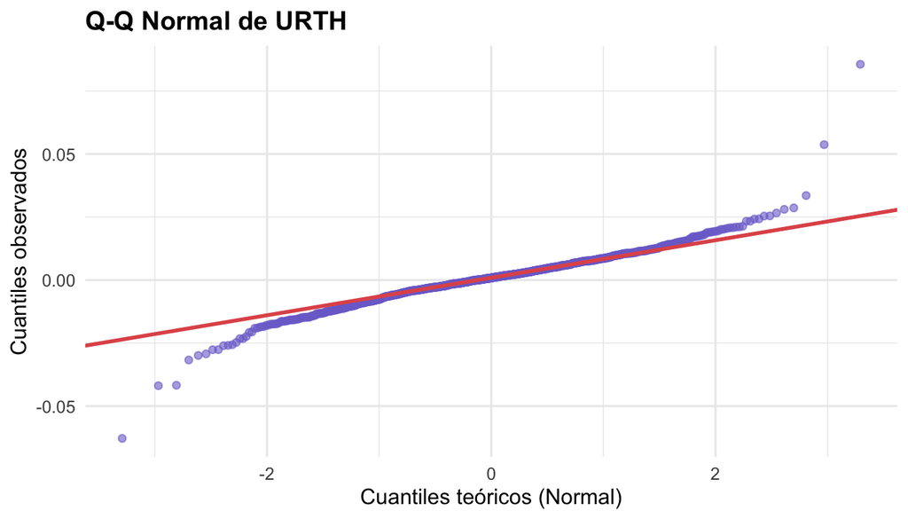

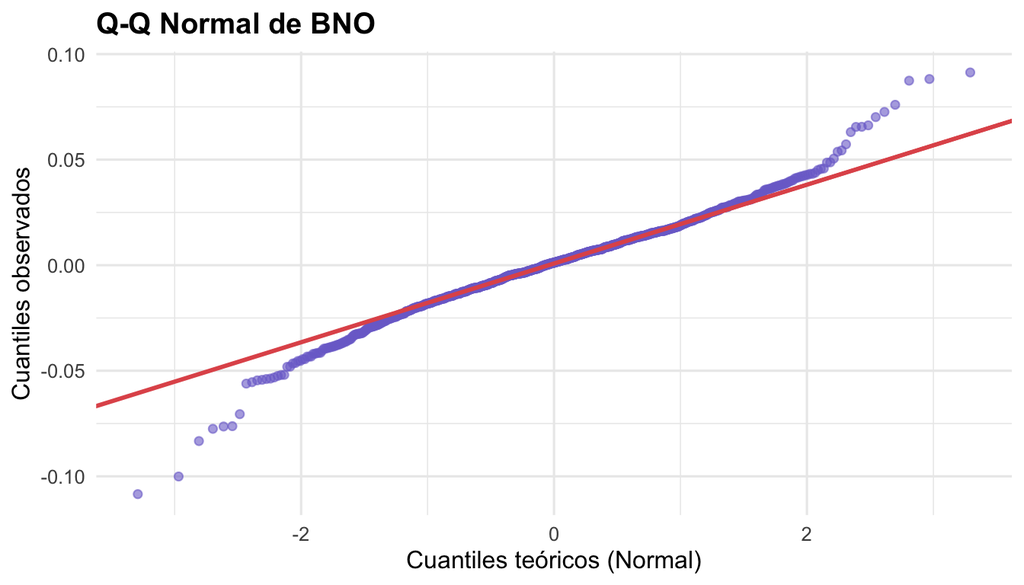

**Interpretación (paso 1).** Si los retornos fueran Normales, los puntos caerían sobre la línea de 45°. Las desviaciones sistemáticas en los extremos —puntos por debajo a la izquierda y por encima a la derecha— evidencian **colas más pesadas que la Normal**, lo que motiva evaluar distribuciones alternativas.

**Paso 2 — Selección de la mejor distribución.** Se ajustan por máxima verosimilitud cuatro distribuciones (Normal, Logística, t de Student y GED) a cada serie y se selecciona la mejor según el test de Kolmogorov–Smirnov (mayor *p-value*; en empate, menor AIC).

URTH — Ajuste de distribuciones y test KS

| Activo | Distribucion | LogVerosimilitud | AIC | BIC | KS_D | KS_p_value |
| --- | --- | --- | --- | --- | --- | --- |
| URTH | Student_t | 3310.632 | -6615.264 | -6600.532 | 0.0181 | 0.8990 |
| URTH | GED | 3301.934 | -6597.869 | -6583.137 | 0.0219 | 0.7216 |
| URTH | Logistica | 3299.400 | -6594.800 | -6584.979 | 0.0275 | 0.4348 |
| URTH | Normal | 3230.896 | -6457.791 | -6447.970 | 0.0667 | 0.0003 |

BNO — Ajuste de distribuciones y test KS

| Activo | Distribucion | LogVerosimilitud | AIC | BIC | KS_D | KS_p_value |
| --- | --- | --- | --- | --- | --- | --- |
| BNO | Student_t | 2450.485 | -4894.971 | -4880.238 | 0.0158 | 0.9634 |
| BNO | GED | 2445.772 | -4885.544 | -4870.812 | 0.0193 | 0.8469 |
| BNO | Logistica | 2447.647 | -4891.294 | -4881.472 | 0.0213 | 0.7525 |
| BNO | Normal | 2414.191 | -4824.382 | -4814.560 | 0.0458 | 0.0295 |

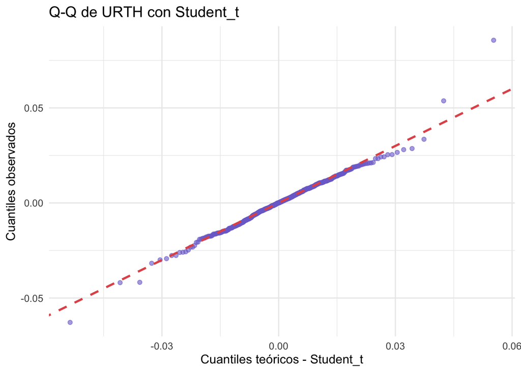

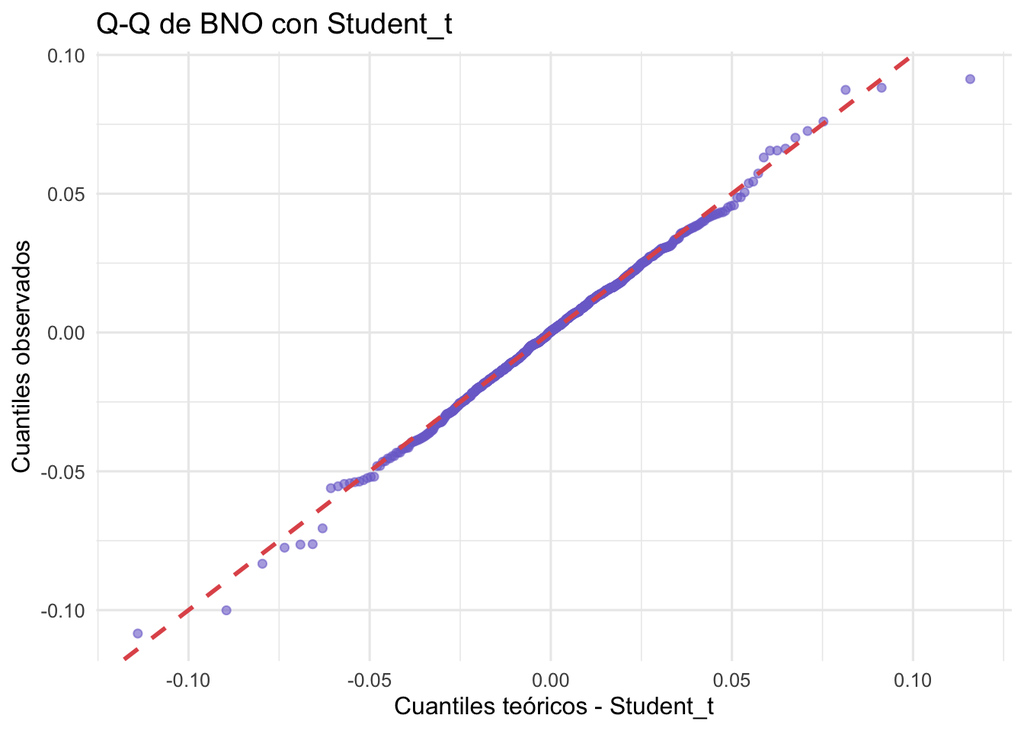

**Interpretación (paso 2).** La distribución seleccionada para URTH es **Student_t** y para BNO **Student_t**. En ambos casos la Normal es rechazada frente a alternativas de **colas más pesadas** (t de Student / GED), lo que confirma el diagnóstico de curtosis elevada del literal a.i: modelar los retornos como Normales subestimaría el riesgo de eventos extremos. El Q-Q plot contra la distribución elegida muestra un ajuste notablemente mejor en las colas que el Q-Q Normal.

A partir de la distribución de URTH se simulan **10.000 precios para T+1** mediante $P_{T+1} = P_T\,e^{R_{T+1}}$.

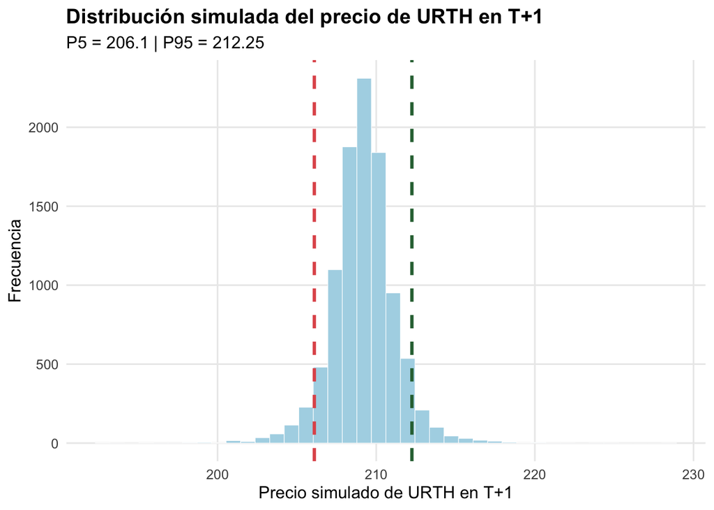

URTH — Precios simulados para T+1 (10.000 escenarios)

| Precio_T | N_Simulaciones | Precio_Esperado | Desv_Estandar | Mediana | Percentil_4 | Percentil_5 | Percentil_95 | Percentil_96 |
| --- | --- | --- | --- | --- | --- | --- | --- | --- |
| 209.07 | 10000 | 209.2 | 2.03 | 209.21 | 205.8 | 206.1 | 212.25 | 212.53 |

**Interpretación.** Partiendo de un precio actual de $209.07, el precio esperado para T+1 es $209.20 —ligeramente por encima del actual, por la deriva positiva de los retornos—. El histograma muestra la distribución simulada de precios: el **90% central** queda comprendido entre el percentil 5% ($206.10) y el percentil 95% ($212.25), señalados con las líneas discontinuas roja y verde. Con estos percentiles podemos afirmar que, en un **escenario no atípico**, el precio de URTH en T+1 se ubicaría dentro de ese rango: aproximadamente el 90% de los escenarios simulados caen ahí y solo el 10% restante —los más extremos— quedaría por fuera. Desde una perspectiva de proyección, no se predice un valor único sino un **abanico de resultados**: la amplitud del intervalo es la medida operativa de la incertidumbre de corto plazo y el insumo natural para fijar bandas de precio, órdenes de cobertura y niveles de alerta.

## 1.7 e) Caminata aleatoria del precio de URTH (20.000 trayectorias, 200 días)

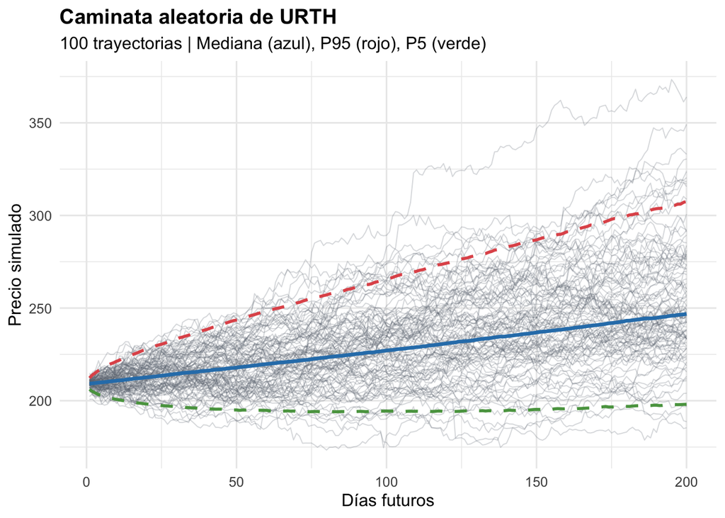

URTH — Mediana y percentiles 5%/95% (inicio y fin del horizonte)

|  | Dia | Media | Mediana | Percentil_5 | Percentil_95 |
| --- | --- | --- | --- | --- | --- |
| 1 | 1 | 209.22 | 209.23 | 206.16 | 212.28 |
| 2 | 2 | 209.43 | 209.39 | 204.95 | 213.96 |
| 3 | 3 | 209.60 | 209.56 | 204.15 | 215.14 |
| 198 | 198 | 248.63 | 246.46 | 197.92 | 306.10 |
| 199 | 199 | 248.85 | 246.58 | 198.01 | 307.07 |
| 200 | 200 | 249.06 | 246.89 | 198.09 | 307.56 |

URTH — VaR y CVaR 95% para T+1 desde la caminata aleatoria

| Metodo | Distribucion | Confianza | Cuantil_Cola | VaR_Pct | CVaR_Pct | VaR_Monetario | CVaR_Monetario |
| --- | --- | --- | --- | --- | --- | --- | --- |
| Caminata Aleatoria (montecarlo) | Student_t simulada | 0.95 | -0.014 | 1.403 | 2.145 | 1402720 | 2145359 |

**Interpretación.** La nube de 100 trayectorias ilustra cómo, partiendo del mismo precio, los caminos posibles se **abren en abanico** con el horizonte: la mediana crece suavemente con la deriva estimada mientras la banda entre los percentiles 5% y 95% se ensancha con $\sqrt{t}$, reflejando que la incertidumbre acumulada aumenta con el tiempo. Al día 200 el rango P5–P95 va de $198 a $308. El mensaje de gestión es claro: **no existe un único “camino esperado”**; la decisión debe apoyarse en la distribución completa de resultados. (iv) El VaR 95% para T+1 derivado de la simulación es 1.40% ($1,402,720), consistente en orden de magnitud con la simulación histórica del literal c. La caminata se simuló con la distribución **Student_t** —la seleccionada en el literal d— en lugar de la Normal, de modo que las trayectorias incorporan las **colas pesadas** de los retornos y no subestiman los escenarios extremos.

## 1.8 f) Volatilidad condicional EWMA de URTH (λ = 0.94)

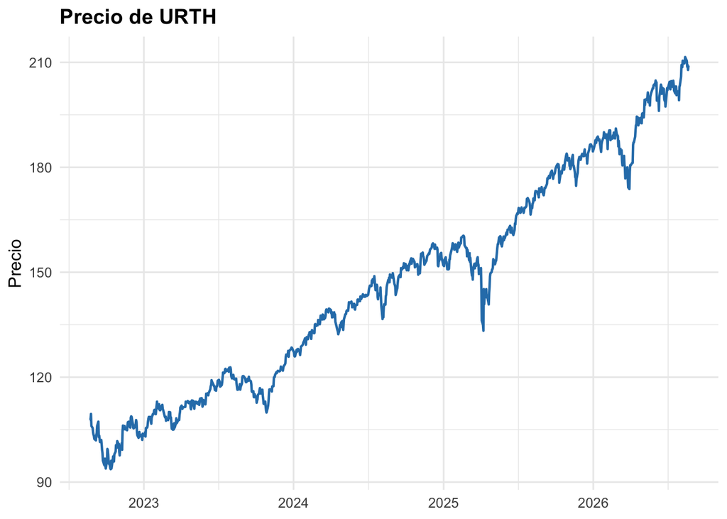

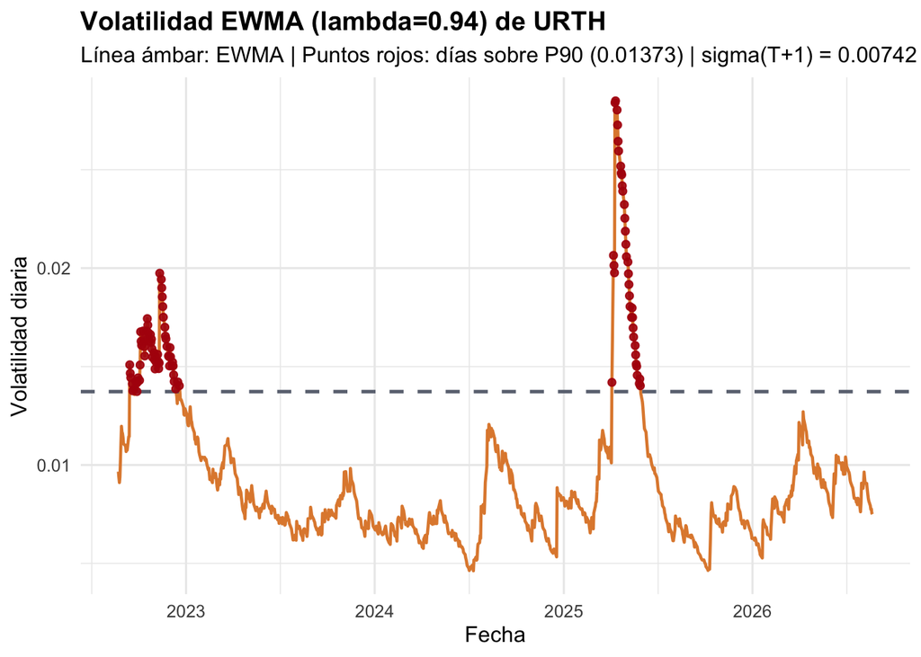

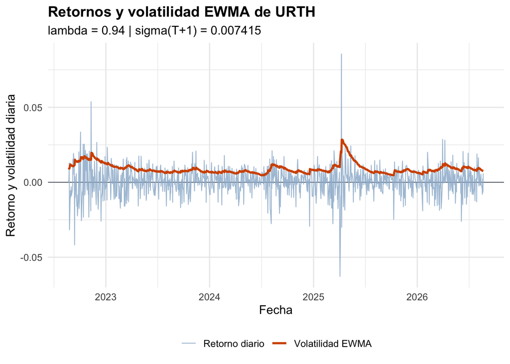

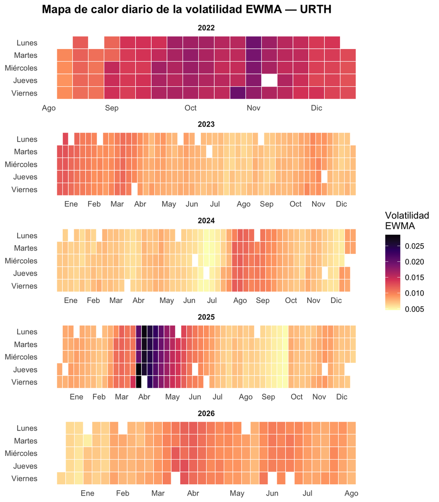

URTH — Principales episodios de ALTA volatilidad (EWMA sobre P90)

| Inicio | Fin | Dias | Vol_Maxima | Vol_Promedio |
| --- | --- | --- | --- | --- |
| 2025-04-04 | 2025-05-29 | 38 | 0.02850 | 0.02034 |
| 2022-09-26 | 2022-12-12 | 55 | 0.01974 | 0.01594 |
| 2022-09-14 | 2022-09-20 | 5 | 0.01509 | 0.01441 |

URTH — Principales periodos de BAJA volatilidad (EWMA bajo P10)

| Inicio | Fin | Dias | Vol_Minima | Vol_Promedio |
| --- | --- | --- | --- | --- |
| 2024-06-10 | 2024-07-22 | 29 | 0.00462 | 0.00538 |
| 2025-09-09 | 2025-10-10 | 24 | 0.00464 | 0.00531 |
| 2024-12-03 | 2024-12-18 | 12 | 0.00533 | 0.00567 |

**Interpretación.** El modelo EWMA pondera exponencialmente los retornos recientes (λ = 0.94), captando el *clustering* de volatilidad típico de los mercados. El pronóstico para el siguiente día hábil es **σ(T+1) = 0.742%**. Las cuatro visualizaciones son complementarias: (1) el **precio** muestra la trayectoria del activo; (2) la **volatilidad EWMA** (línea ámbar) resalta con **puntos rojos** los días que superan el percentil 90, es decir, los picos de tensión; (3) el gráfico de **retornos + EWMA** evidencia cómo la volatilidad se dispara justo cuando los retornos diarios (azul) se vuelven más amplios y bruscos; y (4) el **mapa de calor** localiza en el calendario los focos de alta volatilidad (tonos oscuros), permitiendo identificar de un vistazo los meses de estrés frente a los periodos de calma.

Las tablas de episodios cuantifican ambos regímenes. Los **periodos de alta volatilidad** —el más intenso entre 2025-04-04 y 2025-05-29 (volatilidad máxima 2.85%)— coinciden con **caídas pronunciadas y movimientos bruscos** del precio, y se ven como las zonas oscuras del mapa de calor. Los **periodos de baja volatilidad** —el más prolongado entre 2024-06-10 y 2024-07-22 (29 días bursátiles, volatilidad promedio 0.54%)— corresponden a fases de **mercado tranquilo con tendencia sostenida**, y aparecen como las zonas claras (amarillas) del heatmap. Esta volatilidad condicional —que reacciona al entorno reciente, a diferencia de la desviación estándar histórica constante— es el insumo para el VaR dinámico del literal g.

## 1.9 g) Comparación de metodologías de VaR (exposición USD 100M en URTH)

VaR y CVaR al 95% (T+1) por metodología — URTH

| Metodo | VaR_Pct | CVaR_Pct | VaR_Monetario | CVaR_Monetario |
| --- | --- | --- | --- | --- |
| Monte Carlo t de Student + EWMA | 1.072 | 1.602 | 1072046 | 1601847 |
| Simulación histórica filtrada + EWMA | 1.205 | 1.762 | 1205419 | 1761930 |
| t no estandarizada + EWMA (analítica, sin Monte Carlo) | 1.056 | 1.589 | 1055511 | 1589439 |

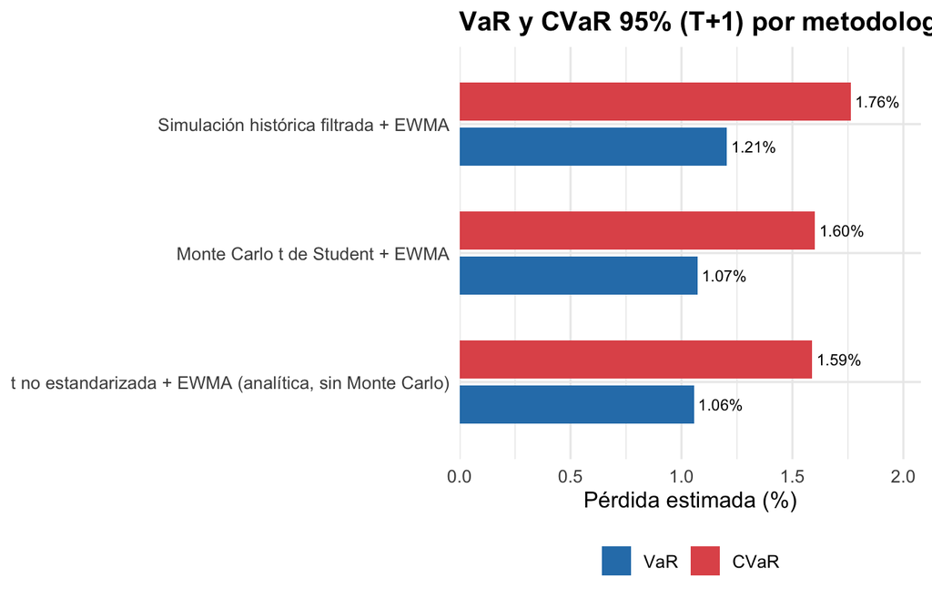

**Metodología.** Se comparan **tres formas de calcular el mismo VaR/CVaR al 95%**, todas ancladas a una única volatilidad de referencia: la volatilidad condicional del día siguiente, σ(T+1) = 0.74%, obtenida con el modelo EWMA (λ = 0.94) descrito arriba. Al compartir esa misma σ(T+1), ninguna diferencia entre los tres resultados se explica por “qué tan alta o baja es la volatilidad”: las tres parten del mismo número. Lo único que cambia entre ellas es **cómo se modela la forma de la cola** de la distribución sobre esa volatilidad:

- **A) Monte Carlo con distribución t de Student + EWMA.** Se simulan 100.000 escenarios de una distribución t de Student (colas más pesadas que la Normal, con los grados de libertad estimados por ajuste de máxima verosimilitud a los retornos de URTH) cuya escala se fija en σ(T+1); el VaR y el CVaR se leen de los percentiles de esa simulación.
- **B) Simulación histórica filtrada + EWMA.** No se asume ninguna forma teórica de distribución: se toman los retornos históricos ya “estandarizados” por su propia volatilidad EWMA de cada día —es decir, la forma empírica real que tuvieron los sustos del pasado reciente, sin suponer que siguen una curva particular— y se reescalan a la σ(T+1) de hoy.
- **C) t de Student + EWMA, fórmula cerrada (sin simulación).** Usa exactamente la **misma** distribución t de la opción A, pero en vez de simular calcula el cuantil y la pérdida esperada con la fórmula matemática cerrada de una t *location-scale*: es el mismo modelo que A, resuelto de forma analítica en lugar de por simulación.

**Interpretación.** El primer resultado a destacar es que **A y C casi coinciden** (VaR 1.07% vs. 1.06%; CVaR 1.60% vs. 1.59%): eso **no es casualidad**, porque C es la fórmula cerrada de exactamente el mismo modelo (t + EWMA) que A aproxima por simulación. Que ambas coincidan es una **validación cruzada**: confirma que la simulación Monte Carlo (100.000 escenarios) converge al valor teórico, y le da sustento a A sin depender solo de la simulación. La **histórica filtrada (B)** —1.21% de VaR, 1.76% de CVaR— difiere de las otras dos porque no impone la forma t: usa la distribución empírica real de los residuos, que puede ser más o menos pesada en la cola que una t ajustada por máxima verosimilitud.

En conclusión, con las tres metodologías ancladas a la **misma** σ(T+1), las diferencias entre ellas aíslan el efecto de la **forma de la cola** (t teórica vs. distribución empírica), no el nivel de volatilidad. Dado que URTH exhibe curtosis alta (literal a.i), y que A y C se validan mutuamente, conviene apoyarse en el **CVaR** y en el resultado de las metodologías t (A y C) como referencia principal de capital en riesgo, usando B como contraste no paramétrico.

# 2 Punto II. Optimización de portafolios (4 acciones)

## 2.1 Selección y justificación de los activos

Se seleccionan cuatro acciones del S&P 500 pertenecientes a **sectores distintos**, buscando fundamentos sólidos y baja correlación entre sí para maximizar el potencial de diversificación:

Activos seleccionados y justificación fundamental

| Ticker | Empresa | Sector | Justificacion |
| --- | --- | --- | --- |
| AVGO | Broadcom Inc. | Tecnología / Semiconductores e infraestructura | Semiconductores y software de infraestructura con exposición a IA; utilidades sólidas y dividendos (motor de retorno con fundamentos). |
| COST | Costco Wholesale Corporation | Consumo básico / Retail de membresías | Retail defensivo de membresías; ingresos recurrentes, crecimiento estable y baja volatilidad (ancla del portafolio). |
| MS | Morgan Stanley | Financiero / Banca de inversión y gestión | Banca de inversión y gestión de patrimonios; sensible al ciclo de mercados y a las tasas de interés. |
| NEM | Newmont Corporation | Materiales / Minería de oro | Minero de oro: alta volatilidad individual pero muy baja correlación con las acciones; potente diversificador y cobertura ante inflación/estrés. |

**Justificación de la selección.** Se eligen cuatro empresas del S&P 500 de **sectores distintos** y con perfiles de riesgo-retorno deliberadamente diferentes, para que el ejercicio de optimización sea instructivo: **tecnología/semiconductores (AVGO) + consumo defensivo (COST) + financiero (MS) + oro (NEM)**. La lógica es triple: (i) responden a *drivers* diferentes —IA y semiconductores, consumo estable de membresías, ciclo de mercados y tasas, y el precio del oro—, por lo que sus **correlaciones son bajas** (destaca el oro, casi un *driver* independiente de las acciones) y la diversificación reduce el riesgo total por debajo del promedio ponderado; (ii) tienen **rendimientos esperados muy dispares** (AVGO, de alto crecimiento, frente a COST/MS/NEM), lo que **extiende verticalmente la frontera eficiente** y hace visible el trade-off riesgo-retorno; y (iii) tienen **volatilidades contrastantes** (COST baja; AVGO y NEM altas), de modo que las restricciones de concentración 10%–50% se vuelven ilustrativas. Un matiz clave: **NEM (oro) tiene volatilidad individual alta pero correlación muy baja con el resto**, así que es un ejemplo de cómo un activo volátil puede *reducir* el riesgo del portafolio. Todas son grandes, líquidas y con historia suficiente para 4 años de datos.

**Tasa libre de riesgo.** Se usa $R_f=$ 4.69% EA, el rendimiento del **bono del Tesoro de EE. UU. a 10 años (US10Y)**. Se elige este plazo largo porque el Punto II es un ejercicio de **asignación estratégica de portafolio**: las decisiones de composición y las cotas de concentración (10%–50%) son para sostenerse en un horizonte de inversión de varios años, no para un solo día, así que una tasa libre de riesgo de largo plazo es la referencia consistente con ese horizonte.

## 2.2 Evolución de los precios

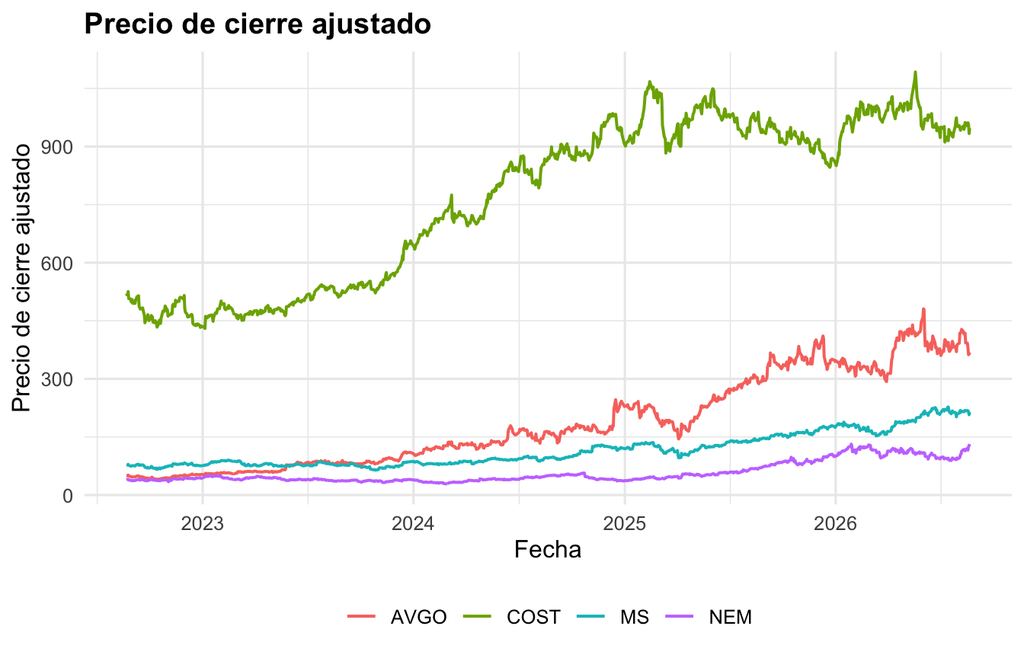

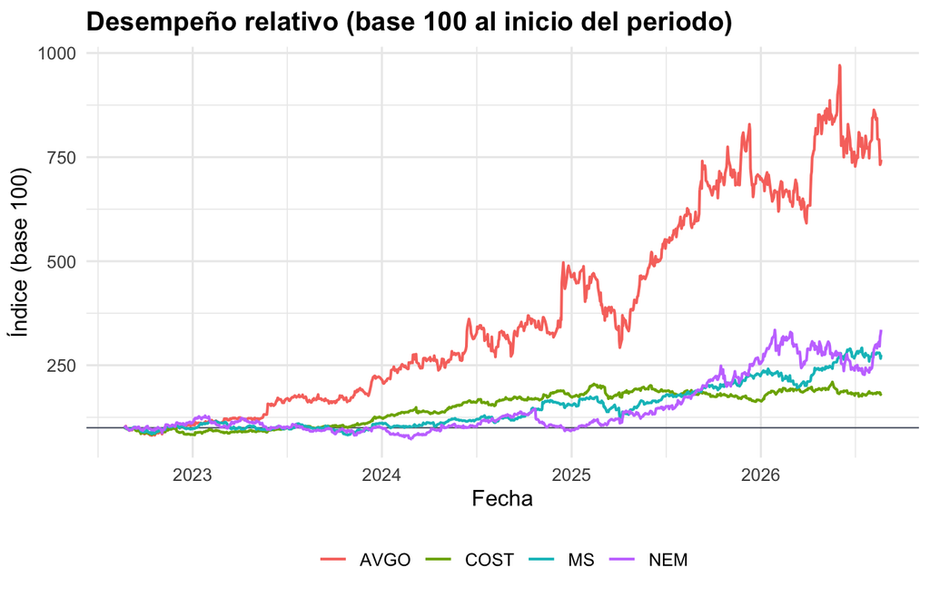

**Interpretación.** El primer gráfico muestra los **precios de cierre ajustados**, útiles para ver niveles, pero difíciles de comparar entre activos con precios muy distintos. El segundo los lleva a **base 100 al inicio del periodo**, de modo que todas las series arrancan en el mismo punto y la altura de cada línea es directamente el **crecimiento porcentual acumulado**: así se compara el desempeño relativo de los activos en igualdad de condiciones e, intuitivamente, se anticipa cuál ha sido el más rentable (mayor pendiente) y cuál el más estable (línea más plana), antes de cuantificarlo en los literales siguientes.

## 2.3 a) Multiplicadores de Lagrange y modelo de Markowitz

**Qué es y para qué sirve (en palabras).** El método de los multiplicadores de Lagrange sirve para **optimizar una función cuando hay restricciones que deben cumplirse exactamente**. Aquí queremos **minimizar el riesgo** de un portafolio, pero no de cualquier manera: los pesos deben **sumar 100%** (se invierte todo el capital) y, opcionalmente, **alcanzar cierto rendimiento**. Lagrange permite incorporar esas condiciones al problema y resolverlo de una sola vez, en lugar de probar combinaciones a mano.

**Notación (la del material del curso).** Trabajamos con **vectores columna**; la transpuesta se escribe con el superíndice $^{T}$ (p. ej. $W^{T}$, *“W transpuesta”*).

- $W$ = vector de **participaciones** (pesos); $E(R)$ = vector de **rendimientos esperados**; $\Sigma$ = **matriz de varianzas–covarianzas**; $\mathbf{1}$ = vector de unos.
- **Rendimiento esperado del portafolio:** $E(R_p)=W^{T}E(R)$.
- **Riesgo (varianza) del portafolio:** $\sigma_p^{2}=W^{T}\Sigma\,W$.
- **Presupuesto:** $\sum_i W_i=W^{T}\mathbf{1}=1$.

**El problema de Markowitz.** Buscamos el portafolio de **mínimo riesgo**:

$$\min_{W}\;\sigma_p^{2}=W^{T}\Sigma\,W
\quad\text{sujeto a}\quad W^{T}\mathbf{1}=1,\quad W^{T}E(R)=E^{*}.$$

La función objetivo $W^{T}\Sigma\,W$ **es** la varianza del portafolio: combina los pesos con la matriz de covarianzas. Minimizarla es, literalmente, encontrar la mezcla de activos con **menor riesgo** para un presupuesto (y, si se fija, un rendimiento) dados.

**Cómo ayuda y qué significan los multiplicadores.** Al resolver este problema con Lagrange aparecen dos multiplicadores, uno por cada restricción, y ambos tienen lectura económica:

- El del **presupuesto** ($\sum_i W_i=1$) refleja el costo de la condición de invertir todo el capital.
- El del **rendimiento objetivo** ($W^{T}E(R)=E^{*}$) es el más informativo: mide **cuánto aumenta el riesgo mínimo si se exige un punto más de rentabilidad** —el “precio” del retorno en unidades de riesgo—, y es lo que da forma a la **frontera eficiente** (al recorrer distintos valores de $E^{*}$ se obtiene, para cada nivel de rentabilidad, el portafolio menos riesgoso posible).

En síntesis, la formulación con Lagrange convierte la pregunta *“¿cómo reparto el capital para arriesgar lo menos posible?”* en un problema con solución directa. La versión **sin cotas** tiene una fórmula cerrada, que usamos como ejemplo abajo; la versión **con las cotas $10\%\le W_i\le 50\%$** del taller se resuelve **numéricamente** en los literales f–i, porque las desigualdades no permiten una fórmula cerrada.

Ejemplo analítico (Lagrange): pesos de mínima varianza global sin cotas

| Activo | Peso |
| --- | --- |
| AVGO | 0.0083 |
| COST | 0.6176 |
| MS | 0.2479 |
| NEM | 0.1263 |

```
Retorno objetivo R* = 0.3657 | lambda = 0.00490 | gamma = 0.12239
```

**Interpretación.** La solución analítica (sin cotas) reparte el capital priorizando los activos que más reducen la varianza conjunta. Los multiplicadores $\lambda$ y $\gamma$ son los precios sombra de las restricciones de presupuesto y de retorno objetivo: indican cuánto variaría la varianza mínima si se relajara marginalmente cada una. En los literales f–i se resuelve la versión **con cotas** ($10\%\le w_i\le 50\%$) mediante optimización numérica (SLSQP), que no admite fórmula cerrada por las desigualdades.

## 2.4 b) Rendimiento promedio efectivo anual de cada activo

Rendimiento efectivo anual por activo

| Activo | Rendimiento_Anual_EA |
| --- | --- |
| AVGO | 0.6556 |
| COST | 0.1626 |
| MS | 0.2894 |
| NEM | 0.3553 |

**Interpretación.** El activo de mayor rendimiento efectivo anual es **AVGO** (65.56%) y el de menor es **COST** (16.26%). Estas cifras reflejan el desempeño histórico de cada empresa en la ventana analizada y son el insumo de retorno esperado ($E(R)$) para la optimización. Un rendimiento alto no es deseable por sí solo: debe evaluarse contra su riesgo (literal c) y su contribución al portafolio.

## 2.5 c) Volatilidad anualizada — activo más volátil

Volatilidad anualizada por activo

| Activo | Volatilidad_Anual |
| --- | --- |
| AVGO | 0.4600 |
| COST | 0.2111 |
| MS | 0.2842 |
| NEM | 0.4000 |

**Interpretación.** El activo **más volátil** es **AVGO** (46.00% anual), mientras que el más estable es **COST** (21.11%). La volatilidad es la medida de riesgo total (sistemático + específico) de cada acción; el activo defensivo (COST) suele mostrar la menor, mientras que el minero de oro (NEM) y el de crecimiento (AVGO) tienden a ser los más volátiles, con la banca (MS) en un nivel intermedio.

## 2.6 d) Correlaciones entre pares — diversificación

Matriz de correlaciones de retornos diarios

|  | AVGO | COST | MS | NEM |
| --- | --- | --- | --- | --- |
| AVGO | 1.000 | 0.212 | 0.398 | 0.205 |
| COST | 0.212 | 1.000 | 0.227 | 0.100 |
| MS | 0.398 | 0.227 | 1.000 | 0.227 |
| NEM | 0.205 | 0.100 | 0.227 | 1.000 |

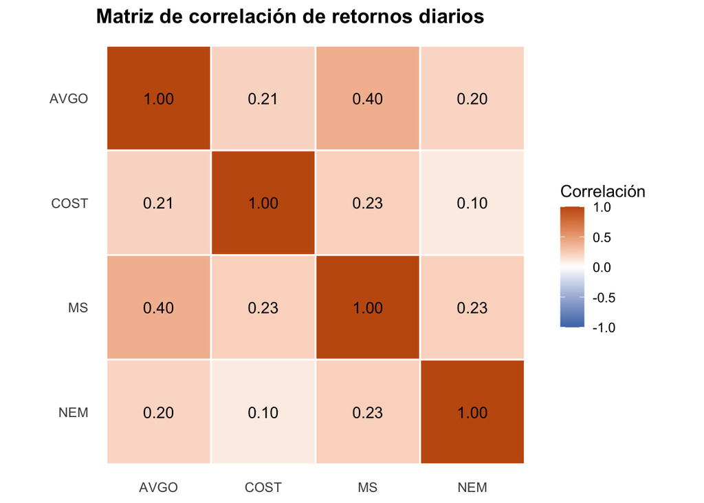

En particular, el par **AVGO–MS presenta una correlación de 0.4**, que según el criterio visto en clase (0.3 ≤ |coeficiente| < 0.6) indica una **relación lineal débil**: tecnología y banca comparten cierta sensibilidad al mismo entorno de mercado. Por su magnitud y, sobre todo, por su **signo positivo**, esta relación implica que en fases de **mercado bajista** ambos activos *podrían* moverse a la baja de forma simultánea, lo que amplificaría el riesgo del portafolio justo cuando menos conviene; es, dentro de la canasta, el par que menos diversificación aporta.

## 2.7 e) Portafolio equiponderado (25% cada activo)

Portafolio equiponderado (25%)

| Portafolio | Peso_AVGO | Peso_COST | Peso_MS | Peso_NEM | Rendimiento | Riesgo | Sharpe |
| --- | --- | --- | --- | --- | --- | --- | --- |
| Equiponderado | 0.25 | 0.25 | 0.25 | 0.25 | 0.3657 | 0.2255 | 1.4141 |

**Interpretación.** Repartir el capital en partes iguales produce un rendimiento anual esperado de 36.57% con un riesgo de 22.55%. Es una estrategia ingenua (no optimizada) pero notablemente eficiente: su riesgo no solo es inferior al del activo más volátil, sino que queda **muy cercano al del activo de menor riesgo del literal c** (COST, 21.11%), pese a incorporar activos mucho más volátiles. Es decir, gracias a la diversificación se obtiene un riesgo casi tan bajo como el del activo más estable pero con la rentabilidad combinada de los cuatro, lo que hace del equiponderado una **buena estrategia “simple”** para un inversionista que no quiere optimizar. Sirve además de punto de comparación para juzgar el valor agregado de la optimización con restricciones.

## 2.8 f) Portafolio de mínima varianza (10% ≤ wᵢ ≤ 50%)

Portafolio de mínima varianza con restricciones

| Portafolio | Peso_AVGO | Peso_COST | Peso_MS | Peso_NEM | Rendimiento | Riesgo | Sharpe |
| --- | --- | --- | --- | --- | --- | --- | --- |
| Mínima varianza | 0.1 | 0.5 | 0.2625 | 0.1375 | 0.2717 | 0.1851 | 1.2143 |

**Interpretación.** Bajo las restricciones de concentración ($10\%\le w_i\le 50\%$, sin apalancamiento), la cartera de mínima varianza concentra el peso en los activos de menor volatilidad y menor correlación (típicamente el defensivo), alcanzando el **menor riesgo posible** (18.51%) dentro del conjunto factible. Es la opción para un inversionista que prioriza la estabilidad sobre la rentabilidad. La cota del 10% evita la concentración excesiva y fuerza cierta exposición a todos los sectores.

## 2.9 g) Portafolio de máximo rendimiento (10% ≤ wᵢ ≤ 50%)

Portafolio de máximo rendimiento con restricciones

| Portafolio | Peso_AVGO | Peso_COST | Peso_MS | Peso_NEM | Rendimiento | Riesgo | Sharpe |
| --- | --- | --- | --- | --- | --- | --- | --- |
| Máximo rendimiento | 0.5 | 0.1 | 0.1 | 0.3 | 0.4796 | 0.2991 | 1.4466 |

## 2.10 h) 10.000 portafolios aleatorios factibles

```
Portafolios simulados: 10000 | Rendimiento medio: 36.54% | Riesgo medio: 23.30%
```

Muestra de portafolios aleatorios factibles

| Rendimiento | Riesgo | Sharpe |
| --- | --- | --- |
| 0.3182 | 0.2036 | 1.3326 |
| 0.4068 | 0.2522 | 1.4271 |
| 0.2990 | 0.1941 | 1.2988 |
| 0.3767 | 0.2302 | 1.4327 |
| 0.3915 | 0.2588 | 1.3315 |

**Interpretación.** La simulación de 10.000 combinaciones de pesos que cumplen las restricciones genera la **nube de portafolios factibles** en el espacio riesgo–rendimiento. Su borde superior izquierdo aproxima la frontera eficiente: ningún portafolio puede situarse por encima y a la izquierda de ella.

## 2.11 i) Frontera eficiente y portafolios dominantes

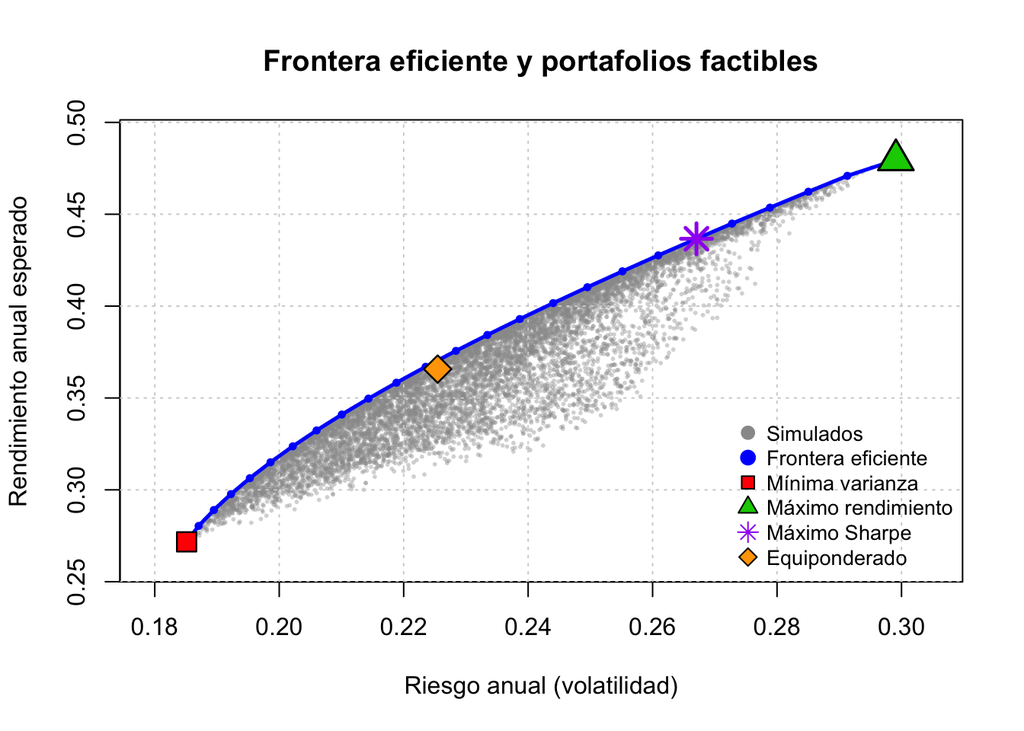

```
Mínima varianza    -> Riesgo = 0.1851 | Rendimiento = 0.2717
```

```
Máximo Sharpe      -> Riesgo = 0.2671 | Rendimiento = 0.4367
```

```
Máximo rendimiento -> Riesgo = 0.2991 | Rendimiento = 0.4796  (extremo sup. derecho)
```

## 2.12 j) Razón de Sharpe y recomendación

Razón de Sharpe por portafolio (Rf = 4.69% EA)

| Portafolio | Rendimiento | Riesgo | Sharpe |
| --- | --- | --- | --- |
| Equiponderado (e) | 0.3657 | 0.2255 | 1.4141 |
| Mínima varianza (f) | 0.2717 | 0.1851 | 1.2143 |
| Máximo rendimiento (g) | 0.4796 | 0.2991 | 1.4466 |
| Mejor aleatorio (h) | 0.4383 | 0.2682 | 1.4594 |
| Máximo Sharpe (i) | 0.4367 | 0.2671 | 1.4595 |

Composición (pesos) del portafolio de máximo Sharpe

| Activo | Peso |
| --- | --- |
| AVGO | 0.4273 |
| COST | 0.1838 |
| MS | 0.1748 |
| NEM | 0.2141 |

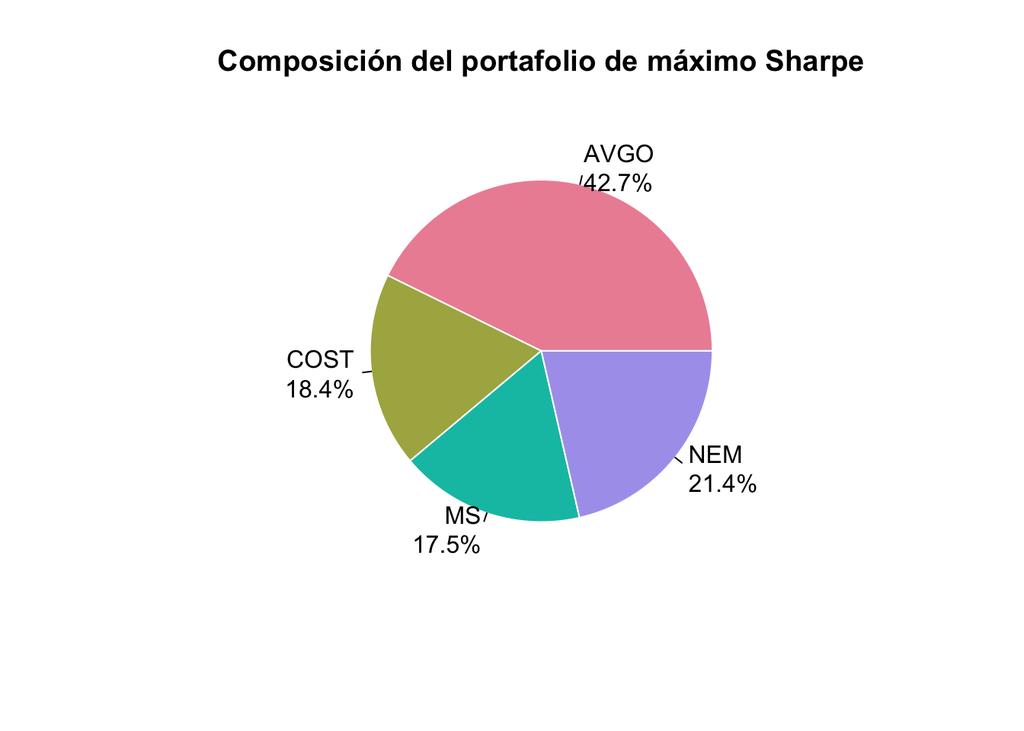

**Interpretación.** Con una tasa libre de riesgo de **4.69% EA**, el portafolio recomendado desde la eficiencia riesgo-retorno es **Máximo Sharpe (i)**, por ofrecer la mayor rentabilidad excedente por unidad de riesgo (mayor Sharpe = 1.459). Su **composición** (tabla y gráfico de pesos) asigna la mayor ponderación a **AVGO** (42.7%) y la menor a **MS** (17.5%), siempre dentro de las cotas 10%–50%. El de mínima varianza es preferible para un inversionista que prioriza la estabilidad, y el de máximo rendimiento para uno tolerante al riesgo que busca maximizar la rentabilidad esperada, pero ninguno supera al de máximo Sharpe en eficiencia (mayor retorno por unidad de riesgo asumido). Vale la pena notar que el **mejor de los 10.000 portafolios aleatorios** del literal h ya alcanza un Sharpe de 1.459, prácticamente **igual** al del óptimo formal (1.459): con suficientes combinaciones simuladas dentro de las restricciones, una búsqueda aleatoria se acerca mucho al resultado de la optimización exacta, aunque esta última sigue siendo el procedimiento correcto y reproducible para llegar a ese punto sin depender de la suerte del muestreo. La recomendación final depende del perfil del inversionista, aunque en términos de teoría de portafolios el punto tangente (máximo Sharpe) es el óptimo cuando se puede combinar con el activo libre de riesgo.

# 3 Punto III — Descomposición espectral de la matriz de varianzas y covarianzas y su relación con el Análisis de Componentes Principales

Cuando se analiza un conjunto de activos, toda la información sobre su **riesgo** conjunto está contenida en la matriz de varianzas y covarianzas $\Sigma$: en la diagonal aparece el riesgo propio de cada activo y, fuera de ella, la forma en que se mueven unos con otros. El problema es que esa información está mezclada. Con cuatro activos hay diez números distintos; ninguno de ellos, mirado por separado, permite saber cuáles son las verdaderas **fuentes** de riesgo de la cartera. La expresión $\sigma_p^{2}=W^{T}\Sigma W$ sirve para medir el riesgo total de un portafolio, pero no dice de dónde proviene ese riesgo ni cuántas fuentes distintas lo originan.

La descomposición espectral resuelve ese problema. Por ser **simétrica**, toda matriz de covarianzas puede **descomponerse** como $\Sigma = V\Lambda V^{T}$, es decir, como una suma de piezas independientes entre sí. Cada pieza está formada por un vector propio y un valor propio. El vector propio es una combinación de los activos, una receta de ponderaciones que indica con qué signo y en qué proporción participa cada uno. El valor propio es la varianza que tiene esa combinación. La relación entre ambos se ve al aplicar la fórmula del riesgo del portafolio: si se invierte siguiendo un vector propio, **la varianza resultante es exactamente su valor propio**. Por eso el valor propio se interpreta de manera directa como el riesgo que carga ese factor.

El Análisis de Componentes Principales es esa descomposición aplicada a los datos. Cada columna definida por un vector propio genera una nueva serie de retornos, que se denomina componente principal. La primera componente es la que concentra **la mayor varianza posible**; la segunda es la de mayor varianza entre las que no están correlacionadas con la primera, y así sucesivamente. Como las componentes no están correlacionadas entre sí, cada una aporta información que las demás no repiten, a diferencia de los activos originales, que suelen decir varias veces lo mismo. Además, la suma de los valores propios coincide con la suma de las varianzas originales: el riesgo total se conserva y solo se reparte de otra forma. Gracias a ello cada valor propio puede expresarse como una **fracción del riesgo total**, que es lo que se conoce como varianza explicada. De ese modo, un conjunto de variables muy correlacionadas queda resumido en unos pocos factores independientes que concentran casi toda la variabilidad de los datos.

Su utilidad en el análisis de factores de riesgo es doble. Por una parte, permite identificarlos. Cuando la primera componente asigna ponderaciones del mismo signo a todos los activos, se interpreta como el **factor de mercado**, esto es, el riesgo sistemático que los arrastra a todos en la misma dirección; las componentes siguientes suelen recoger **contrastes entre sectores o estilos de inversión**. En el análisis de una curva de tasas de interés, las tres primeras componentes se interpretan como nivel, pendiente y curvatura, y en conjunto suelen explicar más del noventa y cinco por ciento de su movimiento, lo que permite sustituir decenas de tasas por tres factores con sentido económico claro. Por otra parte, permite resumirlos: al trabajar con pocos factores no correlacionados se elimina la información repetida, se reduce el número de variables y se obtienen estimaciones más estables del riesgo, algo especialmente valioso cuando hay muchos activos y pocas observaciones.

Para un gestor de portafolios, la lectura más valiosa es la de la varianza explicada. Si la primera componente concentra una proporción muy alta del riesgo total, la cartera está expuesta en realidad **a un único factor por más títulos que contenga**, y su diversificación resulta más **aparente** que real. Si, por el contrario, los valores propios se reparten de forma más pareja, existen fuentes de riesgo genuinamente distintas y la diversificación cumple su función. El análisis no elimina el riesgo, pero lo hace visible, lo ordena y lo cuantifica, lo que permite decidir qué exposiciones se asumen de forma deliberada y cuáles conviene cubrir.

Conviene señalar, por último, dos advertencias. Las componentes son construcciones estadísticas y su interpretación económica debe justificarse en cada caso, pues no surge de manera automática del cálculo. Y como el resultado depende de la escala de las variables, cuando estas no son comparables entre sí se recomienda aplicar el análisis sobre la matriz de correlaciones en lugar de la de covarianzas.

# 4 Punto IV — Análisis de casos: Lectura 7 del CFA

## 4.1 Ejemplo 15. Beta de Westport Innovations

**Modelo:** $(R - R_f) = \alpha + \beta(R_M - R_f) + \varepsilon$. Sesenta observaciones mensuales entre 2009 y 2013. $R_M$ corresponde al índice S&P/TSX Composite.

|  | Coeficiente | Error estándar | t reportado |
| --- | --- | --- | --- |
| Alpha | 0.0267 | 0.0273 | 0.9793 |
| Beta | 1.0788 | 0.3880 | 2.7800 |

$R^2 = 0.1176$ · grados de libertad = 58 · valor crítico $t_c = 2.00$

### 4.1.1 a) Resumen del problema y principales conclusiones

Se pone a prueba si Westport tiene riesgo de mercado promedio, es decir, si $\beta = 1$. El intervalo de confianza resulta $[0.3028;\ 1.8548]$ y contiene el 1; el estadístico $t$ correspondiente es $(1.0788 - 1)/0.3880 = 0.2031$, muy por debajo de 2.00. Por ambos caminos no se rechaza la hipótesis nula: no hay evidencia de que la acción tenga un riesgo sistemático distinto al del mercado. Sí se rechaza en cambio $\beta = 0$ ($t = 2.7800$), lo que confirma que la acción responde al mercado. El $R^2$ de 0.1176 indica que solo el 11.76% de la variación del exceso de retorno proviene del mercado; el 88.24% restante es riesgo propio de la empresa.

### 4.1.2 b) Variable endógena y variable exógena

Endógena: el exceso de retorno de la acción sobre la tasa libre de riesgo, $(R - R_f)$. Exógena: el exceso de retorno del mercado sobre la tasa libre de riesgo, $(R_M - R_f)$.

### 4.1.3 c) Justificación de la clasificación

La causalidad va del mercado a la acción. El índice agrega cientos de compañías y refleja condiciones macroeconómicas generales, mientras que Westport tiene una participación marginal en él y no puede moverlo. Para el inversionista, el retorno del mercado es un dato del entorno que no controla.

### 4.1.4 d) Objetivo del análisis y aporte a las decisiones financieras

Estimar $\beta$ para medir el riesgo sistemático de la acción y comprobar si se aparta del promedio del mercado. El propio ejemplo señala que $\beta$ indica el tamaño de la prima de rentabilidad exigida al título dadas las expectativas sobre el mercado. Además, orienta la construcción de portafolios, porque muestra si el activo amplifica o suaviza los movimientos del mercado, y el $R^2$ permite saber qué parte del riesgo total desaparecería al diversificar.

### 4.1.5 e) Conclusiones

1. El estadístico reportado (2.7800) contrasta $\beta = 0$, no $\beta = 1$. Utilizarlo para la hipótesis de interés habría llevado a la conclusión opuesta: el valor correcto es 0.2031.
2. El intervalo $[0.3028;\ 1.8548]$ es tan amplio que tampoco permitiría descartar una beta de 0.5 ni de 1.8. La causa no es el tamaño de la muestra, que con 60 observaciones es razonable, sino la debilidad de la relación: con un $R^2$ de 0.1176 los residuos son grandes y la pendiente queda mal determinada.
3. El intercepto no es significativo ($t = 0.9793$), de modo que no hay evidencia de retornos anormales. Conviene notar que el coeficiente estimado es económicamente alto, 2.67% mensual, pero su error estándar es aún mayor y el intervalo $[-0.0279;\ 0.0813]$ incluye el cero: la señal queda enterrada en el ruido.
4. Con un $R^2$ de 0.1176, el 88.24% del riesgo de la acción es específico y por tanto desaparece al integrarla en una cartera diversificada. El Ejemplo 18 lo confirma empíricamente: un fondo diversificado del mismo mercado y periodo conserva apenas un 7.21% de riesgo específico.

## 4.2 Ejemplo 16. Valor de empresa y creación de valor

**Modelo:** $EV/IC = b_0 + b_1\,(ROIC - WACC) + \varepsilon$. Datos de corte transversal de nueve empresas de alimentos procesados, año 2001.

|  | Coeficiente | Error estándar | t |
| --- | --- | --- | --- |
| Intercepto | 1.3478 | 0.3511 | 3.8391 |
| Spread | 30.0169 | 3.8519 | 7.7928 |

$R^2 = 0.8966$ · grados de libertad = 7 · valor crítico de una cola $t_c = 1.895$

### 4.2.1 a) Resumen del problema y principales conclusiones

Se contrasta si el diferencial entre la rentabilidad del capital invertido y su costo explica la valoración relativa de la empresa. La hipótesis nula es $H_0: b_1 \le 0$ frente a $H_a: b_1 > 0$, planteada a una sola cola porque la teoría solo admite relación positiva. Con $t = 7.7928$ frente a un crítico de 1.895, se rechaza la nula sin margen de duda. La relación es positiva y muy significativa: el diferencial explica cerca del 90% de por qué unas empresas del sector valen más que otras, y la pendiente implica que un punto porcentual adicional de diferencial se asocia con un aumento de 0.30 en el múltiplo $EV/IC$.

### 4.2.2 b) Variable endógena y variable exógena

Endógena: el múltiplo $EV/IC$. Exógena: el diferencial $(ROIC - WACC)$.

### 4.2.3 c) Justificación de la clasificación

El diferencial resume el desempeño económico de la compañía y resulta de decisiones operativas, de inversión y de financiación que se producen antes de que el mercado las incorpore al precio. El múltiplo $EV/IC$ refleja cómo el mercado valora esa capacidad de crear valor.

### 4.2.4 d) Objetivo del análisis y aporte a las decisiones financieras

Cuantificar cuánto premia el mercado la creación de valor. Permite realizar valoración relativa dentro del sector: las empresas situadas por encima de la recta estarían caras y las que quedan por debajo, baratas, lo que sustenta recomendaciones de compra o venta. Internamente, permite estimar cuánto valor generaría mejorar el ROIC o abaratar el WACC.

### 4.2.5 e) Conclusiones

1. La prueba de una sola cola se justifica porque la teoría anticipa el signo de la relación, y reduce el valor crítico de 2.365 a 1.895, lo que otorga mayor potencia.
2. Con nueve observaciones y siete grados de libertad, los intervalos son anchos y un solo dato atípico puede inclinar la recta. Un $R^2$ de 0.8966 obtenido con esa muestra debe leerse con prudencia, pues con pocas observaciones es relativamente fácil alcanzar ajustes altos.
3. Existe una posible endogeneidad. El valor de empresa se construye como patrimonio más deuda menos caja, y el WACC pondera el costo del patrimonio y de la deuda por su participación en el valor total: ambas variables comparten los valores de mercado del patrimonio y la deuda. Un cambio en la cotización mueve simultáneamente la variable explicada y la explicativa, lo que tensiona el supuesto de que la variable independiente no sea aleatoria y podría sesgar la estimación.
4. La pendiente convierte un principio cualitativo en una meta cuantificable. Para una compañía con un capital invertido de mil millones de dólares, ganar un punto porcentual de diferencial equivale a unos trescientos millones adicionales de valor de empresa, cifra que permite evaluar proyectos concretos.

## 4.3 Ejemplo 17. Insesgadez de los pronósticos de inflación

**Modelo:** *Inflación real* $= b_0 + b_1\,(\text{inflación pronosticada}) + \varepsilon$. Catorce años de datos de la zona euro (índice HICP), entre 1999 y 2013.

|  | Coeficiente | Error estándar | t reportado |
| --- | --- | --- | --- |
| Intercepto | −0.7006 | 0.3723 | −1.8820 |
| Pendiente | 1.5538 | 0.2079 | 7.4722 |

$R^2 = 0.8111$ · grados de libertad = 12 · valor crítico $t_c = 2.18$

### 4.3.1 a) Resumen del problema y principales conclusiones

Si un pronóstico fuera insesgado, lo real coincidiría en promedio con lo anunciado, lo que equivale a una recta de cuarenta y cinco grados: intercepto cero y pendiente uno. Se contrastan por tanto dos hipótesis. Para el intercepto, el intervalo $[-1.5122;\ 0.1110]$ contiene el cero y no se rechaza. Para la pendiente, el intervalo $[1.1006;\ 2.0070]$ no contiene el uno y se rechaza ($t = 2.6638$ frente a 2.18). Como la insesgadez exige ambas condiciones a la vez, basta con que una falle: se concluye que los pronósticos presentan un sesgo sistemático.

El ejemplo cierra con un hallazgo revelador. Al detectar que 2009 constituye un dato atípico, producto de la volatilidad excepcional de la crisis financiera, se reestima la regresión excluyendo ese único año. La pendiente baja a 1.3209 y su intervalo $[0.7984;\ 1.8434]$ sí contiene el uno, de modo que la conclusión se invierte por completo y ya no puede rechazarse que los pronósticos sean insesgados.

### 4.3.2 b) Variable endógena y variable exógena

Endógena: la inflación observada, medida por la variación porcentual del índice HICP. Exógena: la inflación pronosticada por los economistas profesionales.

### 4.3.3 c) Justificación de la clasificación

El argumento es de precedencia temporal: el pronóstico se emite en el primer trimestre y queda fijo, mientras la inflación real se conoce meses después. Una variable ya determinada no puede ser explicada por otra que aún no ha ocurrido. Conviene precisar que la regresión no busca aquí una relación causal, pues la inflación no la causan los pronósticos, sino evaluar la correspondencia entre lo previsto y lo ocurrido, que es un uso distinto y legítimo del modelo.

### 4.3.4 d) Objetivo del análisis y aporte a las decisiones financieras

Determinar si los pronósticos erran siempre en la misma dirección. Un error aleatorio se compensa con el tiempo; uno sistemático se acumula y contamina toda decisión que dependa de él. Los analistas utilizan proyecciones de inflación para asignar activos, descontar flujos y estimar rentabilidades reales; si tienen sesgo conocido, cabe descartarlas o corregirlas con el propio modelo estimado.

## 4.4 Ejemplo 18. Desempeño del Dreyfus Appreciation Fund

**Modelo:** $(R_i - R_f) = \alpha + \beta\,(R_M - R_f) + \varepsilon$. Sesenta observaciones mensuales entre 2009 y 2013.

|  | Coeficiente | Error estándar | t |
| --- | --- | --- | --- |
| Alpha | −0.0012 | 0.0015 | −0.8050 |
| Beta | 0.8660 | 0.0317 | 27.3147 |

$R^2 = 0.9279$ · Análisis de varianza: suma de cuadrados de la regresión 0.0925 (1 grado de libertad) más suma de cuadrados residual 0.0072 (58 grados de libertad), igual a 0.0997 · $F = 746.09$

### 4.4.1 a) Resumen del problema y principales conclusiones

Se evalúa si el fondo rindió más de lo que justificaba el riesgo de mercado asumido. Como señala la lectura, si $\alpha$ fuera cero el retorno esperado del fondo sería $R_f + \beta(R_M - R_f)$, de modo que la beta explicaría por completo su rentabilidad. El alfa estimado es menor que su propio error estándar, con $t = -0.8050$, así que no se rechaza $\alpha = 0$: no hay evidencia de retorno anormal. La beta, en cambio, es rotundamente distinta de cero ($t = 27.3147$). El estadístico $F$, calculado como 0.0925 dividido entre 0.0072/58, resulta 746.09. En conjunto: el fondo es defensivo, pues con una beta de 0.8660 se mueve un 13.4% menos que el mercado; no muestra habilidad medible del gestor, conclusión que se desprende del alfa y no del coeficiente de determinación; y el 92.79% de la variación de su exceso de retorno proviene del mercado.

### 4.4.2 b) Variable endógena y variable exógena

Endógena: el exceso de retorno del fondo sobre la tasa libre de riesgo, $(R_i - R_f)$. Exógena: el exceso de retorno del mercado sobre la tasa libre de riesgo, $(R_M - R_f)$.

### 4.4.3 c) Justificación de la clasificación

El fondo invierte en activos que integran el mercado, de modo que su retorno es una combinación de los componentes del índice: la influencia va del mercado al fondo y no al revés. Además, la evaluación de desempeño requiere que el mercado entre como variable de control para poder aislar lo atribuible al gestor.

### 4.4.4 d) Objetivo del análisis y aporte a las decisiones financieras

Separar la rentabilidad en la parte explicada por el riesgo de mercado y la que no, que es el alfa. Responde si conviene pagar comisiones de gestión activa o comprar un fondo indexado; permite clasificar fondos por perfil de riesgo mediante la beta; y el $R^2$ ayuda a detectar fondos que cobran como activos pero en la práctica replican un índice.

### 4.4.5 e) Conclusiones

1. El análisis de varianza descompone la variación total del fondo en la parte que el mercado explica (0.0925) y la que no (0.0072), que suman el total de 0.0997. De esa descomposición sale directamente el coeficiente de determinación: $0.0925 / 0.0997 = 0.9278$.
2. En una regresión con una sola variable explicativa, el estadístico $F$ es el cuadrado exacto del estadístico $t$ de la pendiente, pues $27.3147^2 = 746.09$, por lo que no aporta información nueva. Su utilidad real aparece en la regresión múltiple, donde permite contrastar de una sola vez si el conjunto de variables explicativas sirve.
3. Una beta de 0.8660 define un fondo defensivo, que amortigua las caídas del mercado pero participa menos de las subidas. Sin un alfa estadísticamente demostrable, la gestión activa difícilmente justifica sus comisiones frente a una alternativa indexada más barata.
4. El contraste con el Ejemplo 15 ofrece la ilustración empírica más clara del efecto de la diversificación: en una acción individual el 88.24% del riesgo era específico, mientras que en un fondo diversificado del mismo mercado y periodo esa proporción cae al 7.21%. Lo que permanece tras diversificar es la exposición al mercado.

## 4.5 Ejemplo 19. Intervalo de predicción para el múltiplo EV/IC

**Modelo:** el mismo del Ejemplo 16, empleado ahora para pronosticar el múltiplo de una empresa con un diferencial $ROIC - WACC$ del 10%.

### 4.5.1 a) Resumen del problema y principales conclusiones

El procedimiento consta de cuatro pasos. La predicción puntual es $1.3478 + 30.0169(0.10) = 4.3495$. La varianza del error de pronóstico se calcula como $s^2\left[1 + \tfrac{1}{n} + \tfrac{(X - \bar{X})^2}{(n-1)s_x^2}\right]$, que con $s = 0.7422$, $n = 9$, $\bar{X} = 0.0647$ y $s_x^2 = 0.004641$ da 0.6306, equivalente a una desviación de 0.7941. Con siete grados de libertad, el valor crítico es 2.365. El intervalo resulta $[2.4715;\ 6.2275]$. Es decir, el múltiplo esperado es 4.35 pero podría situarse en cualquier punto de un rango de casi cuatro unidades. La propia lectura atribuye esa amplitud al reducido tamaño de la muestra.

### 4.5.2 b) Variable endógena y variable exógena

Endógena: el múltiplo $EV/IC$. Exógena: el diferencial $(ROIC - WACC)$. Son las mismas variables del Ejemplo 16, puesto que se trata de la misma regresión utilizada ahora con fines predictivos.

### 4.5.3 c) Justificación de la clasificación

Se mantiene el argumento del Ejemplo 16. En un ejercicio de predicción la distinción resulta aún más nítida: el analista fija el valor de la variable exógena porque corresponde al escenario que quiere evaluar, y el modelo devuelve la endógena, que es la incógnita.

### 4.5.4 d) Objetivo del análisis y aporte a las decisiones financieras

Obtener una predicción y, sobre todo, cuantificar su incertidumbre. Permite entregar un rango defendible en lugar de una cifra única, evaluar escenarios de creación de valor, y reconocer los límites del modelo cuando el intervalo resulta amplio.

### 4.5.5 e) Conclusiones

1. Un pronóstico enfrenta dos fuentes de incertidumbre: el término de error, que existiría aun conociendo los parámetros verdaderos porque los puntos nunca caen exactamente sobre la recta, y el error muestral de los coeficientes estimados. De los tres sumandos de la fórmula, el error irreducible aporta el 87% del total, frente al 10% de la imprecisión de la recta y el 3% de la distancia a la media. La consecuencia es notable: aun con una muestra infinita el intervalo seguiría midiendo 2.91 de ancho frente a los 3.76 actuales, de modo que solo una cuarta parte de la incertidumbre se debe al reducido tamaño de la muestra.
2. El intervalo se ensancha a medida que la predicción se aleja del promedio de la variable explicativa: su amplitud pasa de 3.70 en la media a 5.66 para un diferencial del 30%. Extrapolar fuera del rango observado en la muestra es progresivamente menos confiable.
3. El intervalo de predicción es siempre más amplio que un intervalo de confianza, porque además del error de estimación de los parámetros incorpora el error aleatorio propio del valor individual que se pronostica.
4. Con nueve observaciones, la amplitud del intervalo (3.76) casi iguala la magnitud de la predicción (4.35). El modelo describe razonablemente el patrón del sector pero es débil para pronosticar una empresa concreta, de modo que una compañía que cotice a un múltiplo de 5.0 no está necesariamente sobrevalorada: ese valor cae dentro del intervalo del 95%.

## 4.6 Referencias

CFA Institute (2018). *CFA Program Curriculum 2019, Level II* — Reading 7: *Correlation and Regression*. John Wiley & Sons. Acceso: ProQuest Ebook Central, biblioteca EAFIT (docID 5502859).

Ubicación exacta de cada ejemplo analizado (Sección 3, *Linear Regression*):

| Ejemplo | Páginas | Tablas / Figuras |
| --- | --- | --- |
| 15 — Beta de Westport Innovations | 300–301 | Tabla 9 |
| 16 — EV/IC vs. spread ROIC−WACC | 302–303 | Tabla 10, Figura 11 |
| 17 — Insesgadez de pronósticos de inflación | 304–305 | Tabla 11 |
| 18 — Desempeño del Dreyfus Appreciation Fund | 308–309 | Tabla 12 (con ANOVA) |
| 19 — Intervalo de predicción del EV/IC | 310–311 | Tabla 10 (repetida), Ec. 15 |

Marcos teóricos citados: Sección 3.6 (ANOVA y prueba F, pp. 306–307), Sección 3.7 (intervalos de predicción, pp. 309–310) y Sección 3.8 (limitaciones de la regresión, pp. 309–310).

# 5 Punto V — Modelo de Índice Único (CAPM)

El **Modelo de Índice Único** es la base estadística del **CAPM**: plantea una relación lineal entre el retorno de un activo y el del mercado,

$$R_{i,t} = \alpha_i + \beta_i\,R_{M,t} + \varepsilon_t,$$

donde $\alpha_i$ es el rendimiento anormal, $\beta_i$ el riesgo sistemático (sensibilidad al mercado) y $\varepsilon_t$ el riesgo específico de la empresa. Esa misma beta es el insumo del costo de capital propio por CAPM, $K_e=R_f+\beta\big(E(R_M)-R_f\big)$ (pregunta 10).

Se seleccionan **tres acciones que cotizan en la misma bolsa** y el **índice** que representa ese mercado. La selección se controla en el bloque siguiente.

**Código**

```r
# =============================================================================
# EDITE AQUÍ. Use los símbolos tal como aparecen en Yahoo Finance. Las fechas y
# los días bursátiles se toman de los ya definidos arriba: fecha_inicial/
# fecha_final (mismos ANIOS años) y DIAS_BOLSA. La tasa libre de riesgo de este
# punto es propia (RF_ANUAL_V, distinta de la del Punto II): ver justificación
# abajo.
# =============================================================================
INDICE     <- "^NYA"                 # índice de mercado (NYSE Composite)
ACCIONES   <- c("PG", "TSM", "JPM")  # 3 acciones de la MISMA bolsa que el índice
PESOS_PORT <- c(0.25, 0.30, 0.45)    # pesos del portafolio (pregunta 8), asignados a
                                     # discreción en el orden de ACCIONES: PG 25%,
                                     # TSM 30%, JPM 45% (deben sumar 1 y respetar
                                     # length(ACCIONES); cámbielos aquí si lo desea)
RF_ANUAL_V <- 0.04026                 # tasa libre de riesgo anual EA propia de este
                                     # punto: bono del Tesoro de EE.UU. a 1 año
                                     # (4.026%), horizonte corto consistente con
                                     # el pronóstico T+1 de este punto (distinta
                                     # de la del Punto II, que usa el bono a 10
                                     # años por tratarse de un horizonte de
                                     # inversión de varios años)
# =============================================================================
```

```
Índice: ^NYA | Acciones: PG, TSM, JPM | Observaciones: 1003 | Periodo: 2022-08-23 a 2026-08-21
```

## 5.1 1) Estimación del modelo y parámetros

Estimación CAPM por acción (alpha, beta, IC 95% de beta, R²). p-value con 6 decimales.

|  | Activo | Alpha | p_Alpha_igual_0 | Beta | IC_Beta_Inferior | IC_Beta_Superior | R2 | R2_Ajustado |
| --- | --- | --- | --- | --- | --- | --- | --- | --- |
| PG | PG | -0.0001 | 0.702190 | 0.4173 | 0.3437 | 0.4909 | 0.1100 | 0.1091 |
| TSM | TSM | 0.0010 | 0.148856 | 1.4529 | 1.3041 | 1.6017 | 0.2684 | 0.2677 |
| JPM | JPM | 0.0006 | 0.060927 | 1.1635 | 1.0868 | 1.2403 | 0.4691 | 0.4686 |

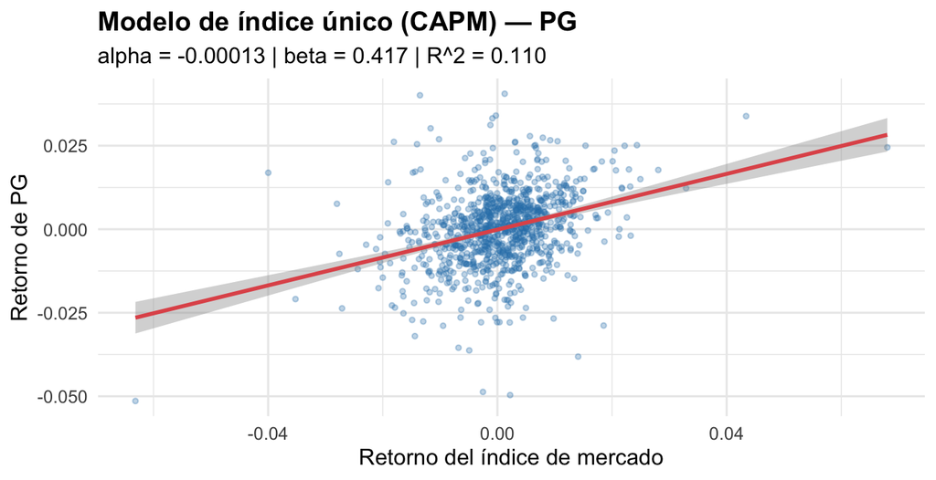

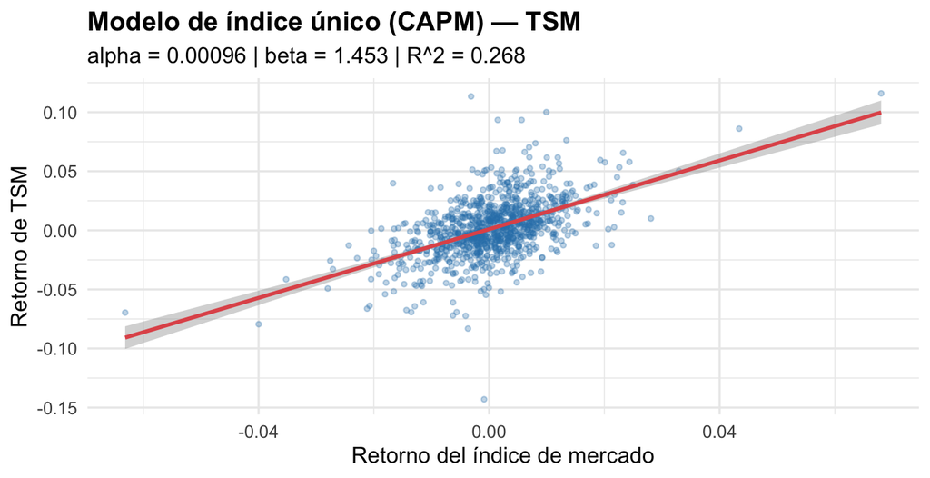

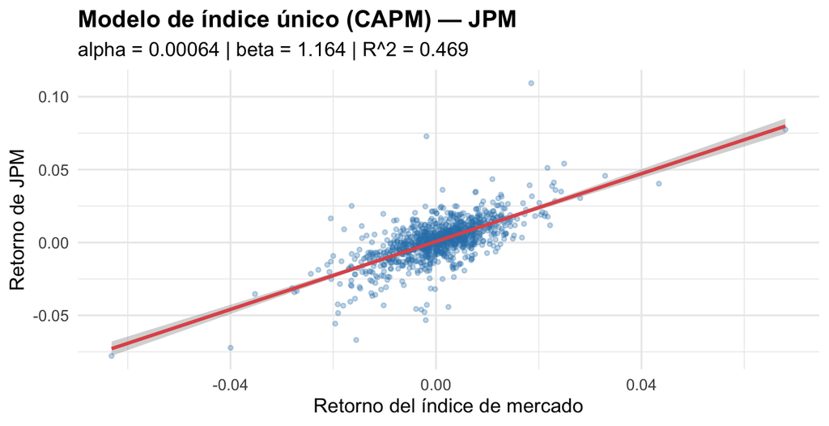

**a) Interpretación de $\alpha$ y $\beta$.** El **intercepto $\alpha$** mide el rendimiento anormal diario: el exceso (o defecto) de rentabilidad que no explica el mercado. La **pendiente $\beta$** es la sensibilidad al mercado: cuánto se mueve, en promedio, el retorno de la acción ante un movimiento del índice. Por acción:

- **PG:** alpha = -0.0001 (no es significativamente distinto de cero (sin evidencia de rendimiento anormal), p-value = 0.702190); beta = 0.42, amortigua los movimientos del mercado.
- **TSM:** alpha = 0.0010 (no es significativamente distinto de cero (sin evidencia de rendimiento anormal), p-value = 0.148856); beta = 1.45, amplifica los movimientos del mercado.
- **JPM:** alpha = 0.0006 (no es significativamente distinto de cero (sin evidencia de rendimiento anormal), p-value = 0.060927); beta = 1.16, amplifica los movimientos del mercado.

**b) Significado financiero de la beta.** La beta es la medida del **riesgo sistemático** (no diversificable) de un activo: indica cuánto amplifica ($\beta>1$) o amortigua ($\beta<1$) los movimientos del mercado. Es el insumo central para el costo de capital (CAPM, pregunta 10) y para decidir la exposición de una cartera al ciclo de mercado; una beta alta promete más retorno cuando el mercado sube, pero también mayores pérdidas cuando cae.

## 5.2 2) ¿Mismo riesgo sistemático que el mercado?

Prueba H0: beta = 1 (mismo riesgo sistemático que el mercado): p-value (6 decimales) y IC 95% vía confint()

|  | Activo | Beta | p_Beta_igual_1 | IC_Beta_Inferior | IC_Beta_Superior | Conclusion_Beta_igual_1 |
| --- | --- | --- | --- | --- | --- | --- |
| PG | PG | 0.4173 | < 0.000001 | 0.3437 | 0.4909 | Se rechaza H0: beta = 1. |
| TSM | TSM | 1.4529 | < 0.000001 | 1.3041 | 1.6017 | Se rechaza H0: beta = 1. |
| JPM | JPM | 1.1635 | 0.000032 | 1.0868 | 1.2403 | Se rechaza H0: beta = 1. |

**a)** Se contrasta $H_0:\beta=1$ frente a $H_a:\beta\neq1$ para cada acción, mediante el estadístico $t=(\hat\beta-1)/s_{\hat\beta}$. La conclusión formal se apoya en el **p-value** de esa prueba: si p-value $<0.05$ (nivel de significancia del 5%), se **rechaza** $H_0$ y la acción tiene un riesgo sistemático estadísticamente distinto al del mercado; si p-value $\ge0.05$, **no se rechaza** y la sensibilidad puede considerarse similar a 1. El **intervalo de confianza al 95%** de $\beta$ es consistente con esa misma prueba y sirve de lectura complementaria: contiene el 1 exactamente cuando no se rechaza $H_0$, y no lo contiene cuando sí se rechaza. Por acción:

- **PG:** beta = 0.42, p-value (H0: beta=1) = < 0.000001, IC 95% = [0.34, 0.49] — Se rechaza H0: beta = 1.
- **TSM:** beta = 1.45, p-value (H0: beta=1) = < 0.000001, IC 95% = [1.30, 1.60] — Se rechaza H0: beta = 1.
- **JPM:** beta = 1.16, p-value (H0: beta=1) = 0.000032, IC 95% = [1.09, 1.24] — Se rechaza H0: beta = 1.

En conjunto, en los **tres casos se rechaza $H_0$**: ninguna de las tres acciones tiene el mismo riesgo sistemático que el mercado.

**b)** Un incremento del **1% en el retorno del mercado** genera, en promedio, un incremento de **$\beta$%** en el retorno esperado de la acción. Por tanto, con $\beta>1$ el efecto es **superior** (amplifica), con $\beta<1$ es **inferior** (amortigua) y con $\beta=1$ es **proporcional**. Por acción:

- **PG:** beta = 0.42 → efecto **inferior** (amortigua).
- **TSM:** beta = 1.45 → efecto **superior** (amplifica).
- **JPM:** beta = 1.16 → efecto **superior** (amplifica).

## 5.3 3) Riesgo sistemático vs. riesgo específico

Descomposición del riesgo: riesgo de mercado (R²) y riesgo específico (1−R²)

|  | Activo | Var_Total | Var_Sistematica | Var_Especifica | R2 | Riesgo_Especifico |
| --- | --- | --- | --- | --- | --- | --- |
| PG | PG | 0.0001 | 0.0000 | 0.0001 | 0.1100 | 0.8900 |
| TSM | TSM | 0.0006 | 0.0002 | 0.0004 | 0.2684 | 0.7316 |
| JPM | JPM | 0.0002 | 0.0001 | 0.0001 | 0.4691 | 0.5309 |

La varianza total de cada acción se descompone como $\mathrm{Var}(R_i)=\beta_i^{2}\mathrm{Var}(R_M)+\mathrm{Var}(\varepsilon_i)$: una parte explicada por el mercado y una parte propia de la empresa.

**a) Proporción de riesgo sistemático.** Coincide exactamente con el **$R^{2}$** de la regresión —la parte del riesgo explicada por el mercado, no diversificable—. Por acción:

- **PG:** 11.0% del riesgo total es sistemático (de mercado).
- **TSM:** 26.8% del riesgo total es sistemático (de mercado).
- **JPM:** 46.9% del riesgo total es sistemático (de mercado).

**b) Proporción de riesgo específico.** Es el complemento, **$1-R^{2}$** —la parte propia de la empresa, diversificable—. Por acción:

- **PG:** 89.0% del riesgo total es específico (propio de la empresa, diversificable).
- **TSM:** 73.2% del riesgo total es específico (propio de la empresa, diversificable).
- **JPM:** 53.1% del riesgo total es específico (propio de la empresa, diversificable).

**c) Interpretación y comparación.** Comparando las tres, la que tiene mayor $R^{2}$ es la más “arrastrada” por el mercado (menos riesgo diversificable), mientras que la de menor $R^{2}$ conserva una proporción mayor de riesgo específico. Para un inversionista diversificado, solo el componente sistemático ($R^{2}$) sobrevive en una cartera amplia; el específico se cancela al combinar activos.

## 5.4 4) Correlación de cada acción con el índice

Correlación acción–índice y R²

|  | Activo | Correlacion | R2 |
| --- | --- | --- | --- |
| PG | PG | 0.3317 | 0.1100 |
| TSM | TSM | 0.5181 | 0.2684 |
| JPM | JPM | 0.6849 | 0.4691 |

El coeficiente de correlación mide la **fuerza de la relación lineal** entre cada acción y el mercado; su cuadrado es exactamente el $R^{2}$ de la regresión. Se usa el criterio de 5 niveles visto en clase: $[0.9,1]$ relación lineal **muy fuerte**, $[0.8,0.9)$ **fuerte**, $[0.6,0.8)$ **moderada**, $[0.3,0.6)$ **débil** y $<0.3$ **sin relación lineal apreciable** (todo en valor absoluto). Por acción:

- **PG:** correlación = 0.33 — relación lineal débil.
- **TSM:** correlación = 0.52 — relación lineal débil.
- **JPM:** correlación = 0.68 — relación lineal moderada.

**a) Comparación entre las tres compañías.** La de mayor correlación (**JPM**) es la que más “acompaña” al índice (mayor riesgo de mercado) y la de menor correlación (**PG**) es la más independiente; en conjunto, las tres caen en zona de relación **débil o moderada**, coherente con que cotizan en la misma bolsa y comparten factores macro comunes.

**b) Qué indican estos coeficientes.** El **signo** indica la dirección de la relación: positivo en las tres acciones, es decir, se mueven en el **mismo sentido** que el mercado (no inverso). La **magnitud**, bajo el criterio de 5 niveles de arriba, indica qué tan sistemático es ese movimiento conjunto: mientras más cerca de 1, más se explica el retorno diario de la acción por el del mercado (menos margen para movimientos idiosincráticos); mientras más cerca de 0, más independiente es la acción del ciclo general del mercado. Al ser exactamente $\sqrt{R^{2}}$, este coeficiente es la misma información de la pregunta 3 expresada en otra escala: fuerza de la relación lineal en vez de proporción de varianza explicada.

## 5.5 5) Limitaciones de la regresión aplicada a los retornos (Lectura 7 del CFA)

Según la **Sección 3.8 de la Lectura 7**, el análisis de regresión tiene limitaciones importantes al estudiar los retornos de los activos:

- **Inestabilidad de parámetros.** Las relaciones de regresión cambian con el tiempo —igual que las correlaciones— porque cambian los contextos económico, fiscal, regulatorio y político. La beta estimada suele diferir de forma notable según el periodo muestral elegido; una beta de hoy puede no describir el riesgo de mañana.
- **Muestreo de más de una población.** El problema más común es mezclar en una misma muestra periodos o regímenes distintos (p. ej. mercados alcistas y bajistas), lo que distorsiona los coeficientes.
- **Violación de los supuestos.** Si se violan los supuestos del modelo (linealidad, homocedasticidad, independencia de los errores, normalidad), las pruebas de hipótesis y los pronósticos dejan de ser válidos. En series financieras son habituales la **heterocedasticidad** (volatilidad no constante) y la **autocorrelación** (dependencia temporal), que sesgan los errores estándar y, con ellos, la inferencia sobre $\alpha$ y $\beta$.

## 5.6 6) Limitaciones en el estudio de los mercados financieros y su efecto

La Lectura 7 añade una limitación propia de los mercados: **el conocimiento público de una relación de regresión puede anular su utilidad futura**. Si un analista descubre que cierta característica predice retornos altos y otros la explotan, los precios se ajustan y la relación deja de sostenerse. Sobre el Modelo de Índice Único, estas limitaciones se traducen en:

- **Sobre la beta.** La inestabilidad de parámetros hace que la beta sea sensible al periodo y a la frecuencia de los datos; una beta estimada con ruido conduce a un costo de capital y a una gestión de exposición imprecisos.
- **Sobre el $R^{2}$.** Depende del régimen de mercado (sube en crisis, cuando las correlaciones aumentan); un $R^{2}$ alto en una ventana no garantiza el mismo poder explicativo en otra.
- **Sobre los pronósticos.** Si los supuestos se violan o la relación cambia, los intervalos de confianza y las predicciones del modelo (pregunta 9) pierden validez, y extrapolar fuera del rango observado es especialmente arriesgado.

## 5.7 7) Comparación de las betas

Betas ordenadas de mayor a menor riesgo sistemático

| Posicion | Activo | Beta |
| --- | --- | --- |
| 1 | TSM | 1.4529 |
| 2 | JPM | 1.1635 |
| 3 | PG | 0.4173 |

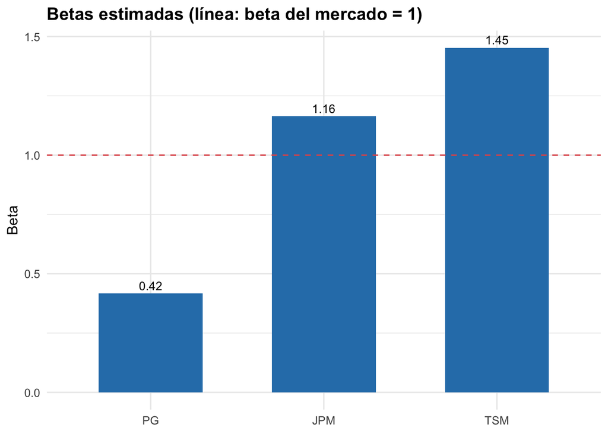

**a)** La acción con **mayor sensibilidad** a las variaciones del mercado es **TSM** (beta más alta).

**b)** El orden de mayor a menor riesgo sistemático es: TSM > JPM > PG.

**c)** La acción con mayor beta **no es necesariamente la mejor inversión**: una beta alta implica más riesgo sistemático y, en un mercado bajista, mayores pérdidas. La decisión debe evaluar el retorno **ajustado por riesgo** (no solo el retorno esperado), el $\alpha$ (habilidad de generar retorno anormal) y el papel del activo dentro de la cartera, no la beta de forma aislada.

## 5.8 8) Beta y riesgo del portafolio

Beta y descomposición de riesgo: riesgo de mercado (R²) y riesgo específico (1−R²), activos vs. portafolio

|  | Activo | Peso | Beta | R2 | Riesgo_Especifico |
| --- | --- | --- | --- | --- | --- |
| PG | PG | 0.25 | 0.4173 | 0.1100 | 0.8900 |
| TSM | TSM | 0.30 | 1.4529 | 0.2684 | 0.7316 |
| JPM | JPM | 0.45 | 1.1635 | 0.4691 | 0.5309 |
|  | Portafolio | NA | 1.0638 | 0.6435 | 0.3565 |

Comparación de la beta del portafolio: regresión vs. promedio ponderado

| Metodo | Beta |
| --- | --- |
| Beta por regresión (portafolio vs. mercado) | 1.063778 |
| Beta por promedio ponderado | 1.063778 |

Los pesos del portafolio (pregunta 8) se asignan a discreción, uno por acción:

- **PG:** peso = 25%.
- **TSM:** peso = 30%.
- **JPM:** peso = 45%.

**a) Estimación de la beta del portafolio.** Se estima de **dos formas equivalentes**: por regresión directa del retorno del portafolio contra el mercado, y como promedio ponderado de las betas individuales, $\beta_p=\sum_i w_i\beta_i$. Las betas individuales que entran en ese promedio ponderado son:

- **PG:** peso = 25%, beta = 0.42.
- **TSM:** peso = 30%, beta = 1.45.
- **JPM:** peso = 45%, beta = 1.16.

El promedio ponderado da $\beta_p=$ 1.064, prácticamente **idéntica** a la beta que se obtiene regresando el retorno del portafolio contra el mercado (1.064, Tabla anterior): ambas formas coinciden, lo que valida el cálculo.

**b) Interpretación económica de la beta obtenida.** Se interpreta como la sensibilidad de la cartera al mercado: un movimiento del 1% del índice mueve, en promedio, 1.06% al portafolio.

**c) Riesgo sistemático y específico del portafolio.** El portafolio tiene un riesgo de mercado (**$R^{2}=$** 0.643, es decir **64.3%**) y un riesgo específico de **35.7%** (Tabla anterior).

**d) Comparación con los activos individuales.** El riesgo de mercado del portafolio es **mayor** que el de cada activo individual (Tabla anterior), porque la diversificación **cancela buena parte del riesgo específico** pero **no** el riesgo de mercado: al combinar acciones, el componente propio de cada empresa se compensa y queda, sobre todo, la exposición común al mercado.

## 5.9 9) Pronóstico por escenarios con intervalo de confianza

**Criterio para definir los escenarios.** Los escenarios se calculan sobre el **retorno del mercado ($R_M$, el índice)**, no sobre el retorno de cada acción: en vez de desplazar la media $\mp 1$ desviación estándar (lo que asume implícitamente una distribución simétrica de los retornos del mercado), los tres escenarios se definen con los **percentiles empíricos** de la propia serie histórica de retornos diarios del índice: **P10** (pesimista), **P50 / mediana** (base) y **P90** (optimista). A partir de esos tres valores de $R_M$ se pronostica el retorno de **cada acción y del portafolio** aplicando su ecuación CAPM ya estimada, $E(R_i)=\hat\alpha_i+\hat\beta_i\,R_M$ (misma lógica que un escenario de mercado aplicado a los activos, ver pregunta 1). Este criterio tiene tres ventajas para este ejercicio: (1) es **no paramétrico** —no exige normalidad, y los retornos diarios del índice típicamente tienen colas más pesadas que la normal—; (2) es **robusto a datos atípicos**, porque un percentil no se mueve tanto como la media ante un puñado de retornos extremos; y (3) mantiene la **coherencia metodológica** con el resto del taller, donde el VaR histórico del Punto I también se calcula por percentiles empíricos de la distribución de retornos, en lugar de supuestos paramétricos.

Los pronósticos se reportan **en términos diarios (T+1)**, deliberadamente **sin anualizar**: anualizar por composición un percentil extremo (P10/P90) equivaldría a asumir que ese único día atípico se repite los 252 días del año, lo que infla artificialmente la cifra (por ejemplo, componer el P90 diario de TSM —la de mayor beta— arrojaría una cifra “anual” de varios cientos por ciento, carente de sentido económico). La anualización sí es razonable para la **media histórica** (pregunta 10, costo de capital), porque ese es un promedio sostenido, no un escenario de un solo día extremo.

### 5.9.1 Escenario pesimista (P10 del mercado)

**Supuesto de mercado.** El retorno diario esperado del índice se ubica en el percentil 10 de su distribución histórica: $R_M=$ -0.971%.

Escenario pesimista: pronóstico E(Ri) T+1 e IC 95%, por acción y portafolio

|  | Activo | Pronostico | IC_inf | IC_sup |
| --- | --- | --- | --- | --- |
| PG.1 | PG | -0.00418 | -0.00516 | -0.00319 |
| TSM.1 | TSM | -0.01314 | -0.01514 | -0.01115 |
| JPM.1 | JPM | -0.01065 | -0.01168 | -0.00962 |
| 1 | Portafolio | -0.00978 | -0.01044 | -0.00912 |

### 5.9.2 Escenario base (P50 del mercado)

**Supuesto de mercado.** El retorno diario esperado del índice coincide con su mediana histórica (percentil 50): $R_M=$ 0.078%.

Escenario base: pronóstico E(Ri) T+1 e IC 95%, por acción y portafolio

|  | Activo | Pronostico | IC_inf | IC_sup |
| --- | --- | --- | --- | --- |
| PG.2 | PG | 0.00020 | -0.00044 | 0.00084 |
| TSM.2 | TSM | 0.00209 | 0.00079 | 0.00339 |
| JPM.2 | JPM | 0.00155 | 0.00088 | 0.00222 |
| 2 | Portafolio | 0.00138 | 0.00095 | 0.00180 |

### 5.9.3 Escenario optimista (P90 del mercado)

**Supuesto de mercado.** El retorno diario esperado del índice se ubica en el percentil 90 de su distribución histórica: $R_M=$ 1.012%.

Escenario optimista: pronóstico E(Ri) T+1 e IC 95%, por acción y portafolio

|  | Activo | Pronostico | IC_inf | IC_sup |
| --- | --- | --- | --- | --- |
| PG.3 | PG | 0.00410 | 0.00314 | 0.00505 |
| TSM.3 | TSM | 0.01566 | 0.01372 | 0.01759 |
| JPM.3 | JPM | 0.01241 | 0.01141 | 0.01341 |
| 3 | Portafolio | 0.01131 | 0.01067 | 0.01195 |

### 5.9.4 Respuestas

**a) Pronóstico de cada acción bajo cada escenario.** Para cada acción se pronostica $E(R_i)=\hat\alpha_i+\hat\beta_i\,R_M$ en los tres valores de $R_M$ de arriba. En orden pesimista → base → optimista:

- **PG:** -0.418% (pesimista) → 0.020% (base) → 0.410% (optimista).
- **TSM:** -1.314% (pesimista) → 0.209% (base) → 1.566% (optimista).
- **JPM:** -1.065% (pesimista) → 0.155% (base) → 1.241% (optimista).

**b) Pronóstico del portafolio bajo cada escenario.** Con la misma lógica, aplicada al retorno del portafolio ($\hat\alpha_p$, $\hat\beta_p$ de la pregunta 8):

- **Portafolio:** -0.978% (pesimista) → 0.138% (base) → 1.131% (optimista).

**d) Cómo cambian el riesgo y la rentabilidad esperada entre escenarios.** Al pasar de pesimista a optimista, el retorno esperado **crece más rápido en las acciones de beta alta** (mayor pendiente, ver bullets del literal a), que también son las que más caen en el escenario adverso: el mayor rendimiento potencial viene acompañado de mayor riesgo, coherente con la interpretación de la beta (pregunta 1).

## 5.10 10) Costo de capital propio (CAPM)

Costo de capital propio (CAPM). Rf = 4.03% EA, E(Rm) = 12.74% EA

| Activo | Beta | Ke_anual |
| --- | --- | --- |
| PG | 0.4173 | 0.0766 |
| TSM | 1.4529 | 0.1669 |
| JPM | 1.1635 | 0.1417 |
| Portafolio | 1.0638 | 0.1330 |

El costo de capital propio se calcula con la fórmula del CAPM: $K_e=R_f+\beta\big(E(R_M)-R_f\big)$, usando $R_f=$ 4.03% EA (el bono del Tesoro de EE. UU. a **1 año**, tasa propia de este punto: ver justificación en el bloque de configuración de arriba, distinta de la tasa a 10 años del Punto II) y la rentabilidad esperada del índice $E(R_M)$. Este último valor **no es un supuesto arbitrario**: se calcula a partir del propio retorno diario promedio del índice ^NYA durante el periodo analizado, $E(R_M)_{diario}=$ 0.0476%, anualizado por composición, $E(R_M)=(1+E(R_M)_{diario})^{252}-1=$ 12.74% EA.

**a) Costo de capital propio de cada compañía.** Por acción:

- **PG:** beta = 0.42, Ke anualizado = 7.66%.
- **TSM:** beta = 1.45, Ke anualizado = 16.69%.
- **JPM:** beta = 1.16, Ke anualizado = 14.17%.

**a mayor beta, mayor $K_e$**, porque el mercado exige más rentabilidad a los activos con más riesgo sistemático.

**b) Costo de capital propio del portafolio.** Con su beta ponderada ($\beta_p=$ 1.064), el portafolio tiene un $K_e$ anualizado de **13.30%**, que queda entre los de sus tres componentes individuales, acorde con su beta ponderada.

**c) Relación entre costo de capital y riesgo sistemático.** Al comparar las cuatro filas de la tabla, la relación es **directa y monótona**: la acción/portafolio con mayor beta es también la de mayor $K_e$, porque ambos miden lo mismo desde ángulos distintos —la beta es la cantidad de riesgo sistemático, y el $K_e$ es la compensación que el mercado exige por asumirlo—.

**d)** La alternativa más atractiva no es simplemente la de mayor retorno esperado, sino la que ofrece el mejor balance entre **beta, riesgo sistemático, retorno esperado y costo de capital**: una acción con beta y $K_e$ altos solo conviene si su retorno esperado supera con holgura ese costo exigido.

## 5.11 11) Gradiente y matriz Hessiana en la estimación por MCO

**Función objetivo.** Estimar la regresión $R_i=b_0+b_1 R_M+\varepsilon$ por mínimos cuadrados equivale a minimizar la suma de errores al cuadrado:

$$S(b_0,b_1)=\sum_{t=1}^{n}\big(y_t-b_0-b_1 x_t\big)^2,$$

donde $y_t=R_{i,t}$ y $x_t=R_{M,t}$.

**Gradiente.** Las derivadas parciales respecto a los parámetros son:

$$\frac{\partial S}{\partial b_0}=-2\sum_t\big(y_t-b_0-b_1 x_t\big),\qquad
\frac{\partial S}{\partial b_1}=-2\sum_t x_t\big(y_t-b_0-b_1 x_t\big).$$

Igualar el gradiente a cero (condición de primer orden) da las **ecuaciones normales**, cuya solución son los estimadores MCO:

$$\hat b_1=\frac{\sum_t (x_t-\bar x)(y_t-\bar y)}{\sum_t (x_t-\bar x)^2},\qquad
\hat b_0=\bar y-\hat b_1\bar x.$$

**Matriz Hessiana.** Las segundas derivadas forman la Hessiana:

$$H=\begin{pmatrix}\dfrac{\partial^2 S}{\partial b_0^2} & \dfrac{\partial^2 S}{\partial b_0\partial b_1}\\[2mm]
\dfrac{\partial^2 S}{\partial b_1\partial b_0} & \dfrac{\partial^2 S}{\partial b_1^2}\end{pmatrix}
=2\begin{pmatrix} n & \sum_t x_t\\ \sum_t x_t & \sum_t x_t^2\end{pmatrix}=2\,X^{\top}X.$$

**Interpretación y condición de segundo orden.** En palabras simples: el **gradiente igualado a cero** dice que, en $(\hat b_0,\hat b_1)$, la suma de errores al cuadrado ya no se puede reducir moviéndose un poco en ninguna dirección —es un punto “plano”—, pero un punto plano por sí solo no basta para saber si es un **mínimo** o un **máximo**: la pendiente es cero en ambos casos, y lo único que los distingue es la **curvatura** de la función alrededor de ese punto. Esa curvatura es exactamente lo que mide la **Hessiana**: aquí es **constante** (no depende de $b$) y **definida positiva**, porque su determinante, $4\big(n\sum x_t^2-(\sum x_t)^2\big)=4n\sum_t(x_t-\bar x)^2$, es siempre positivo mientras $x$ no sea constante. Una Hessiana definida positiva significa que $S$ tiene forma de **“tazón” convexo**: crece en cualquier dirección que uno se aleje del punto plano, sin excepción. Por eso ese punto plano solo puede ser un **mínimo**, y además es el único que existe, es decir, un **mínimo global**. En conjunto, gradiente (condición de primer orden) y Hessiana (condición de segundo orden) son la garantía matemática de que los coeficientes que entrega `lm()` no son un resultado numérico arbitrario, sino **la recta que realmente minimiza el error de ajuste**.

**Apoyo gráfico.** La siguiente superficie dibuja $S(b_0,b_1)$ alrededor del óptimo para la acción PG: al ser un paraboloide (un “tazón” sin picos ni zonas planas adicionales), cualquier punto que se aleje del mínimo (marcado en rojo) queda en un nivel más alto de $S$, sin importar la dirección — esa es, visualmente, la propiedad que garantiza la Hessiana definida positiva.

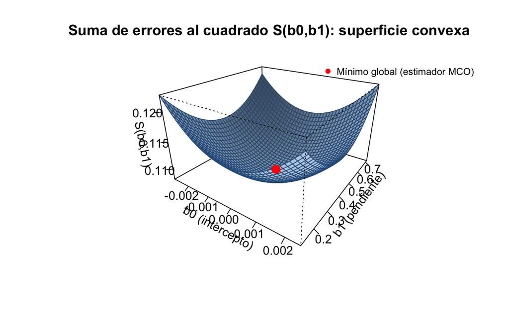

```
Verificación numérica (acción PG ):
```

```
  Gradiente en el óptimo (≈ 0): -0.000000000000000222, 0.0000000000000000514
```

```
  Valores propios de la Hessiana: 2006, 0.1533
```

```
  Hessiana definida positiva: TRUE
```

**Verificación.** Los dos valores propios de la Hessiana son **positivos**, lo cual —en lugar de revisar el signo del determinante— es la forma directa de comprobar que es definida positiva. El gradiente evaluado en los coeficientes estimados por `lm()` da un número **prácticamente cero** (del orden de $10^{-16}$, el margen de error numérico de R, no una diferencia real). Ambos resultados, junto con la superficie convexa del gráfico anterior, confirman con los datos reales de este ejercicio —y no solo en teoría— lo que se planteó arriba: la recta estimada es el mínimo global de la suma de errores al cuadrado.

*Nota.* Todos los cálculos usan retornos logarítmicos diarios de los últimos 4 años del índice ^NYA y de las acciones seleccionadas (mismo periodo `fecha_inicial`–`fecha_final` de los Puntos I y II). La tasa libre de riesgo de este punto (4.03% EA, bono del Tesoro a 1 año — distinta de la del Punto II) y los pesos del portafolio son supuestos editables en el bloque de configuración de este punto.

# 6 Extra — Portafolios alternos (solo gráficos)

Sección adicional para **explorar cómo se comportan otras acciones**. Se generarán únicamente los gráficos —matriz de correlación, frontera eficiente y composición de los portafolios equiponderado, de mínima varianza y de máximo rendimiento—, sin tablas ni interpretaciones

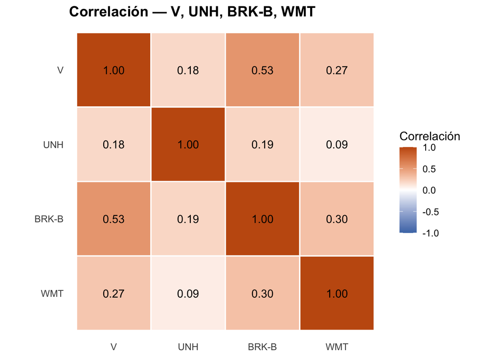

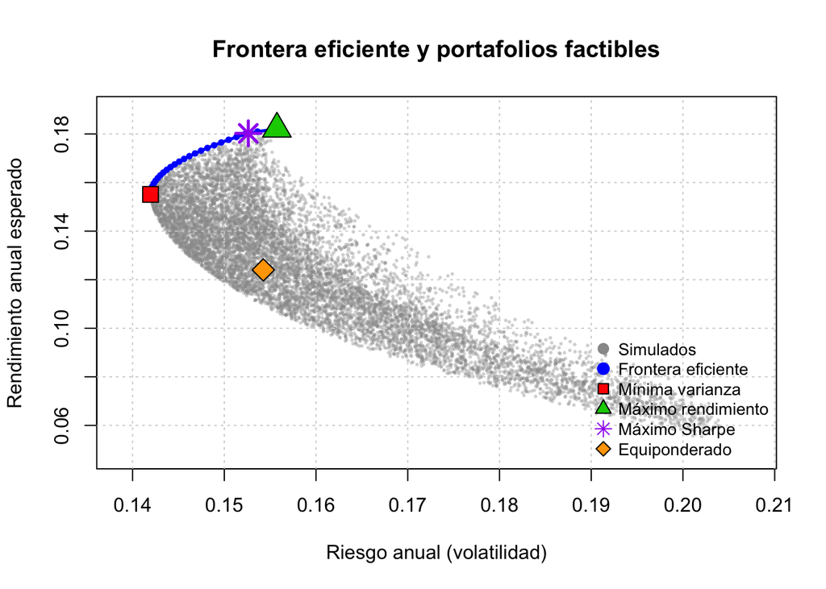

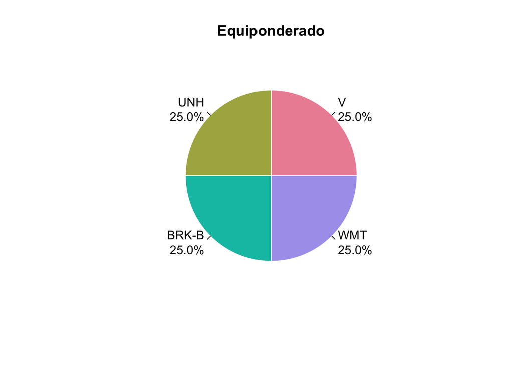

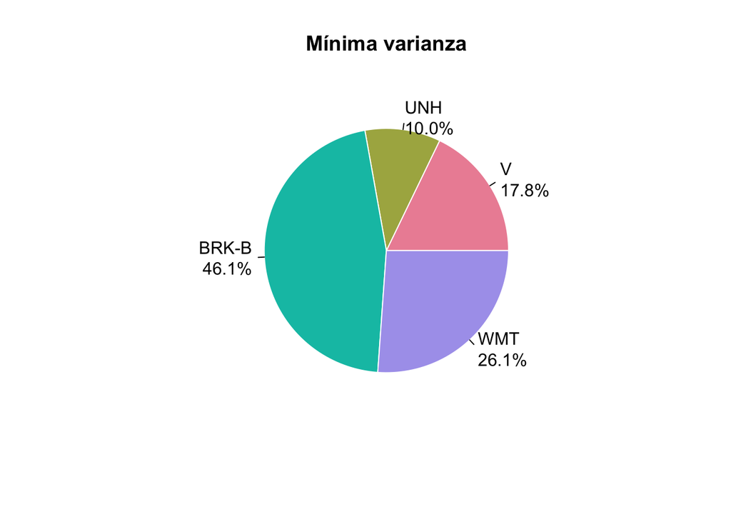

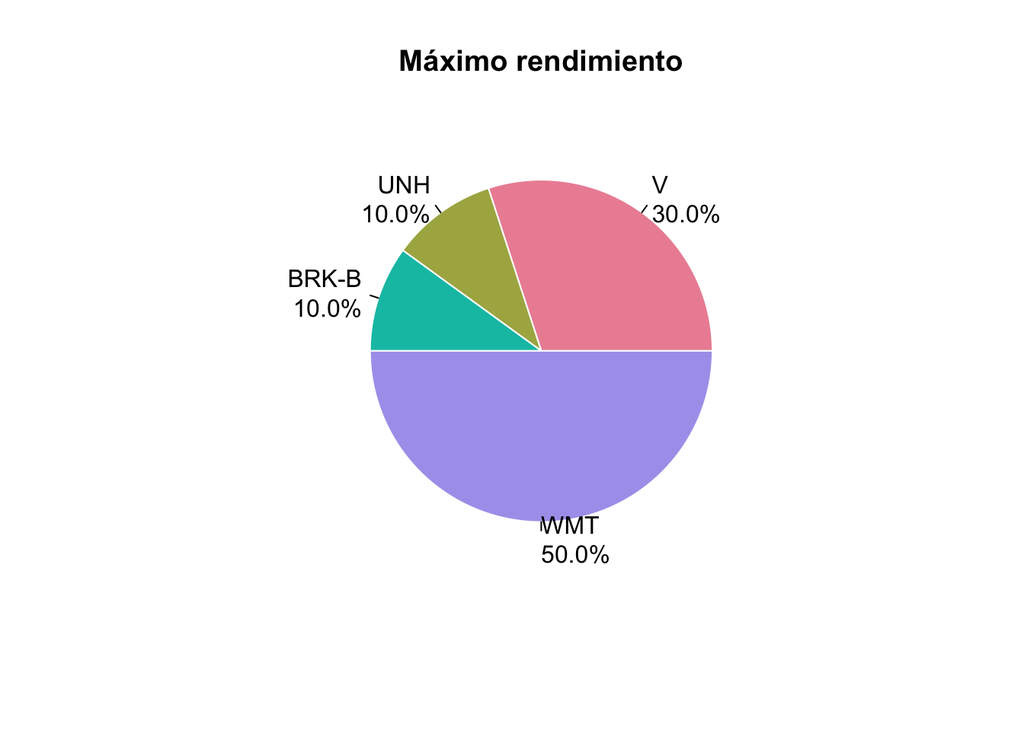